# ProPELL Survey Codebook

This document provides comprehensive documentation of all variables assessed in the 25 ProPELL surveys. All questionnaires were administered via LimeSurvey.

Author

ProPELL/MBieleke

Published

August 24, 2026

**Home** / Survey Documentation

# Introduction

## Survey Organization

The ProPELL study comprises **25 surveys** administered over a 21-week study period:

- **s00** – Screening survey (online)
- **s01–s21** – Weekly surveys during the 21-week study
  - Surveys with suffix **`o`** = completed online from home
  - Surveys with suffix **`l`** = completed on-site in the laboratory

**Example:** Survey `s08o` = Week 8, online completion | Survey `s12l` = Week 12, on-site lab completion

## Survey Names

The surveys in this codebook are named after the week in which they were collected: s00 represents the screening survey prior to the study and s01 to s21 represent the surveys during the 21 weeks of the study. The suffix indicates whether the questionnaire was completed on site in the laboratory (i.e., l) or online from home (i.e., o). For example, participants completed survey s08o online in Week 8.

The survey data are available as individual datasets in the [ProPELL Data Hub](https://cloud.uni-konstanz.de/index.php/f/128545600). They can be joined as necessary using the anonymous participant IDs.

## Anonymized Participant IDs

The participant IDs in these datasets are anonymized, as the code generated by the participants during the study (e.g., IKTENT20) only allows for pseudonymized data.

The mapping of anonymous and pseudonymous IDs is available [here](https://cloud.uni-konstanz.de/index.php/f/130413290) (only authorized PIs; requires login).

## Variable Naming Convention

Each variable has a prefix indicating when it was assessed:

| Prefix | Assessment Timing |
| --- | --- |
| `m0` | Screening survey |
| `m1` | Pre-exercise survey |
| `m2` | Post-exercise survey |
| `m3` | Follow-up survey |
| `w01`–`w21` | Weekly surveys (weeks 1-21) |

*Example:* `m1_birthyear` = participant’s birthyear assessed in pre-exercise survey

## Navigating This Codebook

Use the table of contents on the left to browse surveys by week and timing (online/lab). Each survey section includes:

- **Item-level documentation** – Individual questions, response options, and descriptive statistics
- **Response distributions** – Histograms and frequency tables
- **Summary statistics** – Completion rates, means, medians, standard deviations
- **Source information** – Project context, contact person, and references

# Overview

# Screening Survey

### Age of participant

**Overview**

- **Variable Stem: `age`**
- **Time Points:** m0
- **Reference:** Custom item

**Details**

What is your age (in years)?

**Distribution**

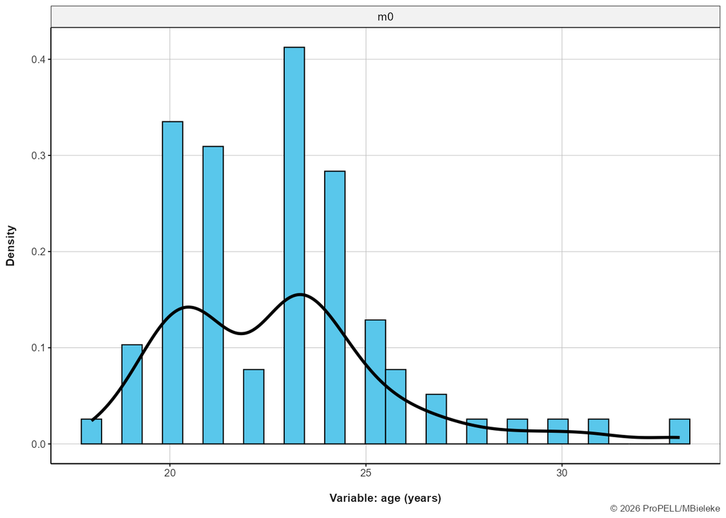

**Statistics**

| Time | N | % | %Val | Mean | SD | Min | Median | Max |
| --- | --- | --- | --- | --- | --- | --- | --- | --- |
| m0 | 75 | 75 | 100 | 22.83 | 2.89 | 18 | 23 | 33 |

### Subjective rating of physical fitness

**Overview**

- **Variable Stem: `fit`**
- **Time Points:** m0
- **Reference:** Petersen et al. (2021)

**Details**

How do you rate your own physical fitness?

**Distribution**

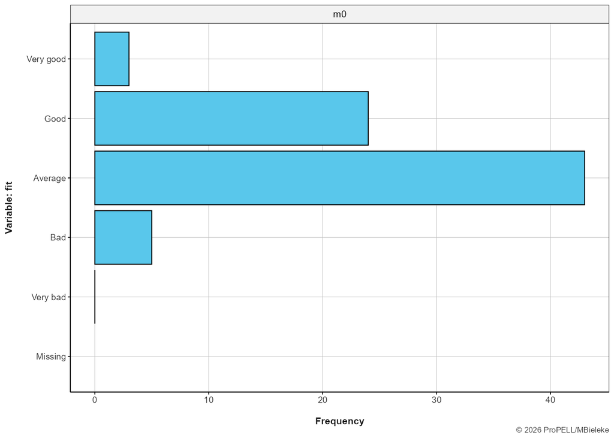

**Statistics**

| Answer | N | % | %Val |
| --- | --- | --- | --- |
| **Very good** |  |  |  |
| m0 | 3 | 4.0 | 4.0 |
| **Good** |  |  |  |
| m0 | 24 | 32.0 | 32.0 |
| **Average** |  |  |  |
| m0 | 43 | 57.3 | 57.3 |
| **Bad** |  |  |  |
| m0 | 5 | 6.7 | 6.7 |
| **Very bad** |  |  |  |
| m0 | 0 | 0.0 | 0.0 |

### Body height

**Overview**

- **Variable Stem: `height`**
- **Time Points:** m0
- **Reference:** Custom item

**Details**

What is your height (in cm)?

**Distribution**

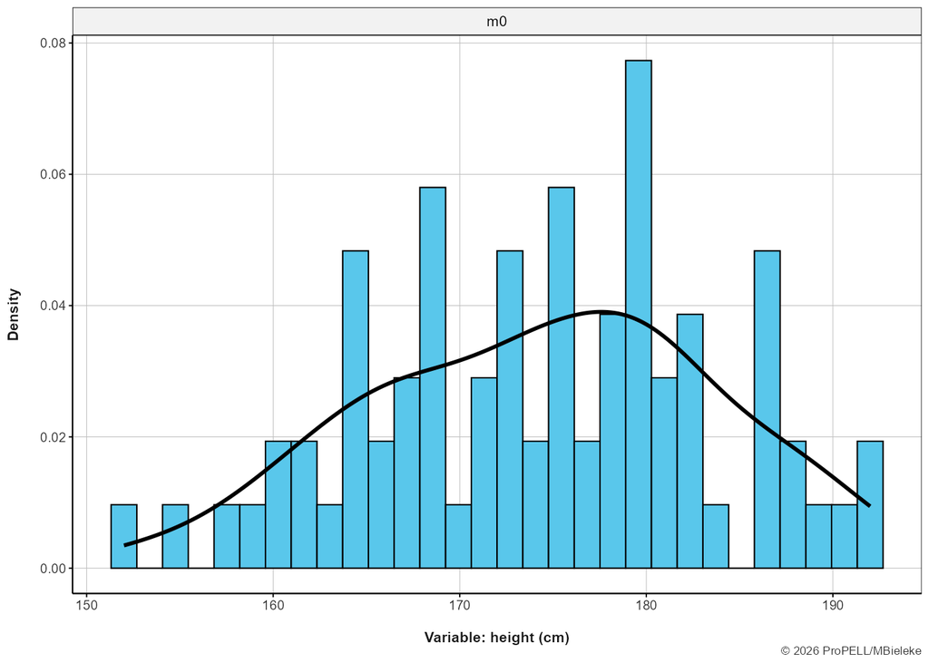

**Statistics**

| Time | N | % | %Val | Mean | SD | Min | Median | Max |
| --- | --- | --- | --- | --- | --- | --- | --- | --- |
| m0 | 75 | 75 | 100 | 174.37 | 9.22 | 152 | 175 | 192 |

### IPAQ-SF 6 Months - Frequency of moderate activity

**Overview**

- **Variable Stem: `ipaq6m01`**
- **Time Points:** m0
- **Reference:** Craig et al. (2003)

**Details**

Again, please think only about physical activities that you performed for at least 10 minutes continuously. On how many days per week during the last 6 months did you usually engage in moderate physical activities such as carrying light loads, cycling at a regular pace, or swimming at a regular pace? Walking is not included.

**Distribution**

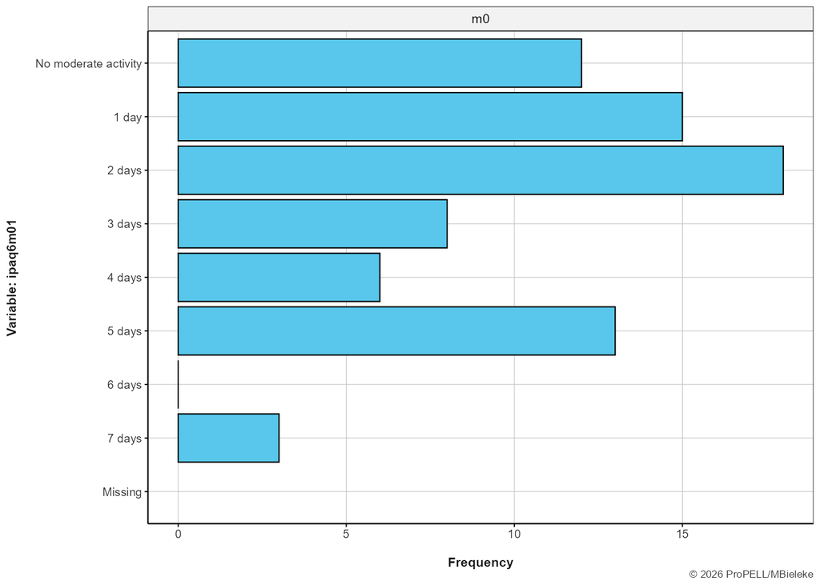

**Statistics**

| Answer | N | % | %Val |
| --- | --- | --- | --- |
| **No moderate activity** |  |  |  |
| m0 | 12 | 16.0 | 16.0 |
| **1 day** |  |  |  |
| m0 | 15 | 20.0 | 20.0 |
| **2 days** |  |  |  |
| m0 | 18 | 24.0 | 24.0 |
| **3 days** |  |  |  |
| m0 | 8 | 10.7 | 10.7 |
| **4 days** |  |  |  |
| m0 | 6 | 8.0 | 8.0 |
| **5 days** |  |  |  |
| m0 | 13 | 17.3 | 17.3 |
| **6 days** |  |  |  |
| m0 | 0 | 0.0 | 0.0 |
| **7 days** |  |  |  |
| m0 | 3 | 4.0 | 4.0 |

### IPAQ-SF 6 Months - Duration of moderate activity

**Overview**

- **Variable Stem: `ipaq6m02`**
- **Time Points:** m0
- **Reference:** Craig et al. (2003)

**Details**

How much time did you usually spend in moderate physical activity on one of those days? Please enter the duration in hours:minutes. For example: 40 minutes ==> 00:40 / one hour ==> 01:00 / two and a half hours ==> 02:30

**Distribution**

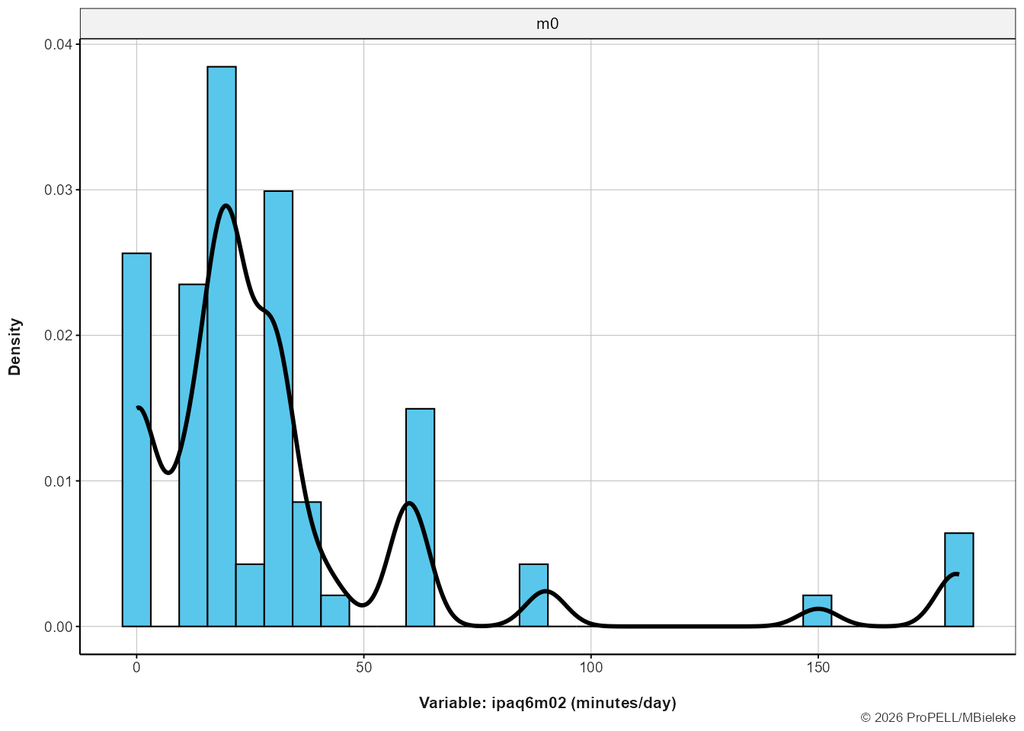

**Statistics**

| Time | N | % | %Val | Mean | SD | Min | Median | Max |
| --- | --- | --- | --- | --- | --- | --- | --- | --- |
| m0 | 75 | 75 | 100 | 32.73 | 38.84 | 0 | 20 | 181 |

### IPAQ-SF 6 Months - Duration of sitting

**Overview**

- **Variable Stem: `ipaq6s`**
- **Time Points:** m0
- **Reference:** Craig et al. (2003)

**Details**

How much time did you usually spend sitting on a typical weekday in the last 6 months? This may include time spent sitting at a desk, visiting friends, sitting or lying in front of the television and sitting in public transport. Please specify the duration as hours:minutes.

**Distribution**

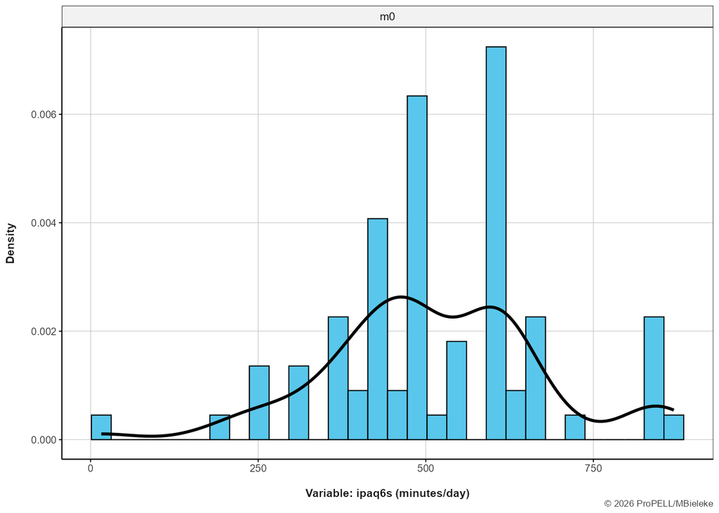

**Statistics**

| Time | N | % | %Val | Mean | SD | Min | Median | Max |
| --- | --- | --- | --- | --- | --- | --- | --- | --- |
| m0 | 75 | 75 | 100 | 512.28 | 161.5 | 16 | 480 | 870 |

### IPAQ-SF 6 months - Frequency of vigorous activity

**Overview**

- **Variable Stem: `ipaq6v01`**
- **Time Points:** m0
- **Reference:** Craig et al. (2003)

**Details**

Please think only about physical activities that you performed for at least 10 minutes continuously. On how many days per week during the last 6 months did you usually engage in vigorous physical activities such as aerobics, running, fast cycling, or fast swimming?

**Distribution**

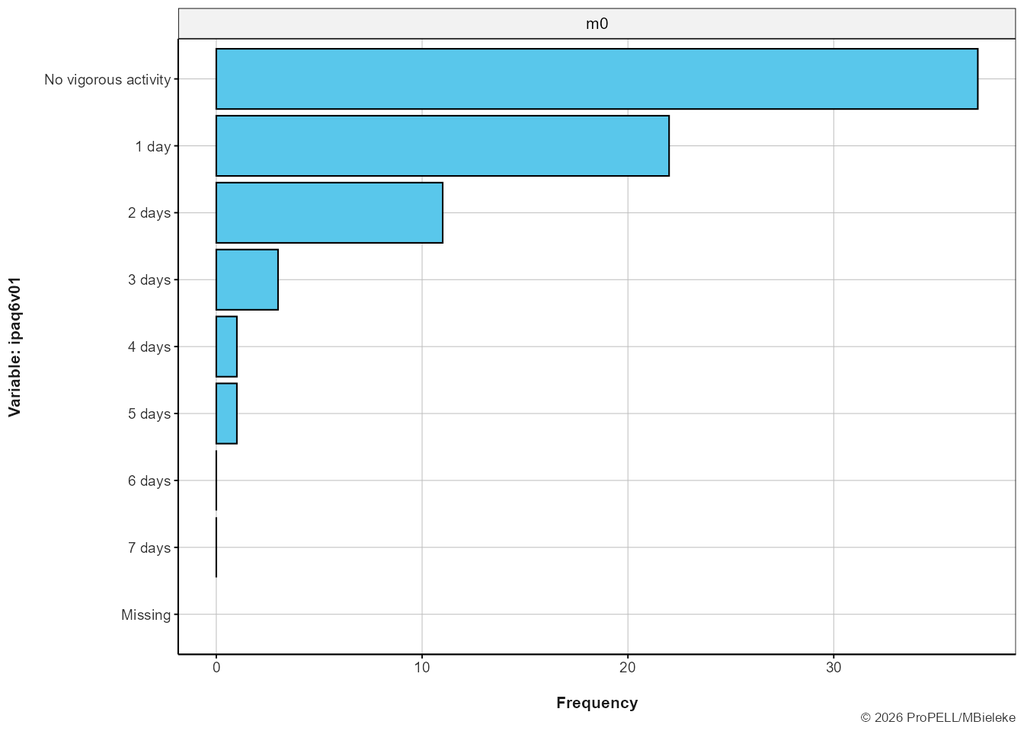

**Statistics**

| Answer | N | % | %Val |
| --- | --- | --- | --- |
| **No vigorous activity** |  |  |  |
| m0 | 37 | 49.3 | 49.3 |
| **1 day** |  |  |  |
| m0 | 22 | 29.3 | 29.3 |
| **2 days** |  |  |  |
| m0 | 11 | 14.7 | 14.7 |
| **3 days** |  |  |  |
| m0 | 3 | 4.0 | 4.0 |
| **4 days** |  |  |  |
| m0 | 1 | 1.3 | 1.3 |
| **5 days** |  |  |  |
| m0 | 1 | 1.3 | 1.3 |
| **6 days** |  |  |  |
| m0 | 0 | 0.0 | 0.0 |
| **7 days** |  |  |  |
| m0 | 0 | 0.0 | 0.0 |

### IPAQ-SF 6 months - Duration of vigorous activity

**Overview**

- **Variable Stem: `ipaq6v02`**
- **Time Points:** m0
- **Reference:** Craig et al. (2003)

**Details**

How much time did you usually spend on one of those days doing vigorous physical activity? Please enter the duration in hours:minutes format. For example: 40 minutes ==> 00:40 / one hour ==> 01:00 / two and a half hours ==> 02:30

**Distribution**

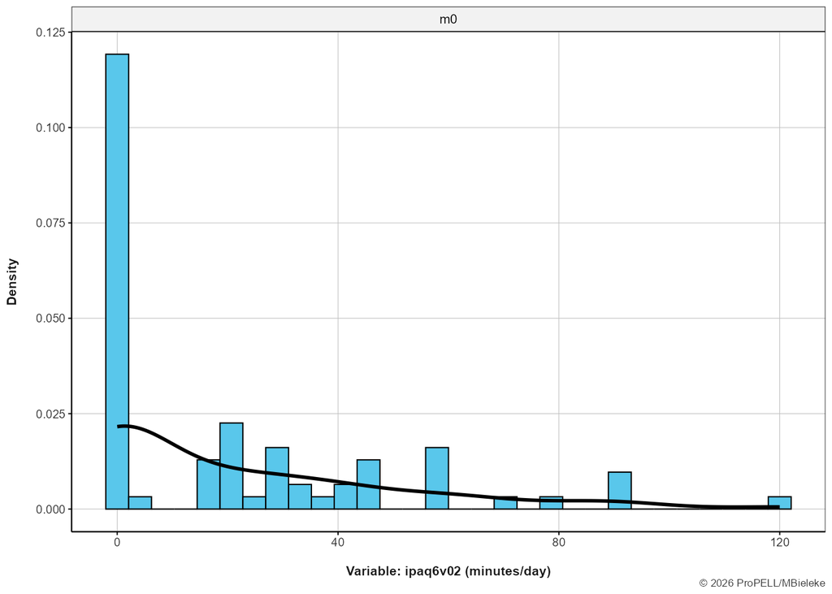

**Statistics**

| Time | N | % | %Val | Mean | SD | Min | Median | Max |
| --- | --- | --- | --- | --- | --- | --- | --- | --- |
| m0 | 75 | 75 | 100 | 21.15 | 28.11 | 0 | 3 | 120 |

### IPAQ-SF 6 Months - Frequency of walking

**Overview**

- **Variable Stem: `ipaq6w01`**
- **Time Points:** m0
- **Reference:** Craig et al. (2003)

**Details**

On how many days per week have you usually walked for at least 10 minutes at a time without interruption during the last 6 months? This includes walking at home or at work, walking from one place to another, and any other walking for recreation, exercise or leisure.

**Distribution**

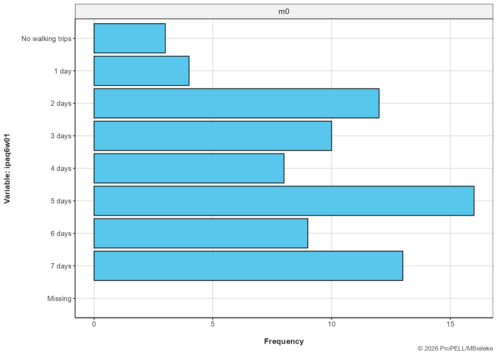

**Statistics**

| Answer | N | % | %Val |
| --- | --- | --- | --- |
| **No walking trips** |  |  |  |
| m0 | 3 | 4.0 | 4.0 |
| **1 day** |  |  |  |
| m0 | 4 | 5.3 | 5.3 |
| **2 days** |  |  |  |
| m0 | 12 | 16.0 | 16.0 |
| **3 days** |  |  |  |
| m0 | 10 | 13.3 | 13.3 |
| **4 days** |  |  |  |
| m0 | 8 | 10.7 | 10.7 |
| **5 days** |  |  |  |
| m0 | 16 | 21.3 | 21.3 |
| **6 days** |  |  |  |
| m0 | 9 | 12.0 | 12.0 |
| **7 days** |  |  |  |
| m0 | 13 | 17.3 | 17.3 |

### IPAQ-SF 6 Months - Duration of walking

**Overview**

- **Variable Stem: `ipaq6w02`**
- **Time Points:** m0
- **Reference:** Craig et al. (2003)

**Details**

How much time did you usually spend walking on one of those days? Please enter the duration in hours:minutes. For example: 40 minutes ==> 00:40 / one hour ==> 01:00 / two and a half hours ==> 02:30

**Distribution**

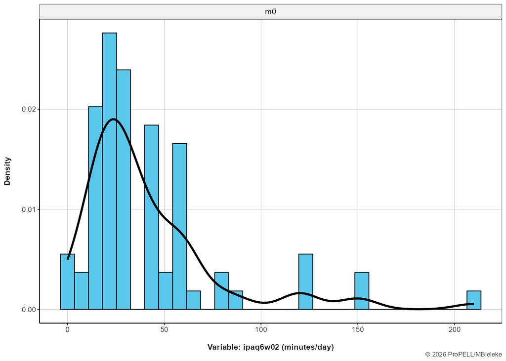

**Statistics**

| Time | N | % | %Val | Mean | SD | Min | Median | Max |
| --- | --- | --- | --- | --- | --- | --- | --- | --- |
| m0 | 75 | 75 | 100 | 41.96 | 37.09 | 0 | 30 | 210 |

### Subjective rating of physical activity relative to peers

**Overview**

- **Variable Stem: `relfit`**
- **Time Points:** m0
- **Reference:** Custom item

**Details**

Imagine that the following scale represents the typical physical activity of people of your age and sex. A value of 0 represents people with the lowest level of physical activity (in terms of the amount of movement, sport and training). A value of 100 represents people with the highest level of physical activity. Please indicate your own position on this scale:

**Distribution**

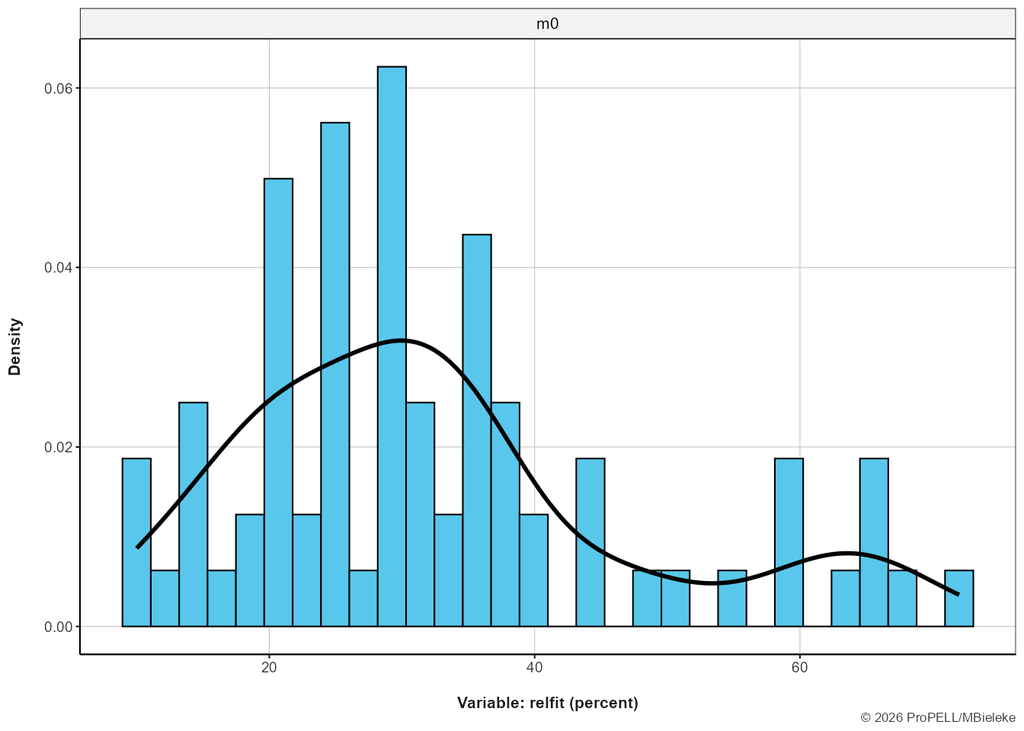

**Statistics**

| Time | N | % | %Val | Mean | SD | Min | Median | Max |
| --- | --- | --- | --- | --- | --- | --- | --- | --- |
| m0 | 75 | 75 | 100 | 32.68 | 15.13 | 10 | 30 | 72 |

### Biological sex of participant

**Overview**

- **Variable Stem: `sex`**
- **Time Points:** m0
- **Reference:** Custom item

**Details**

What is your sex?

**Distribution**

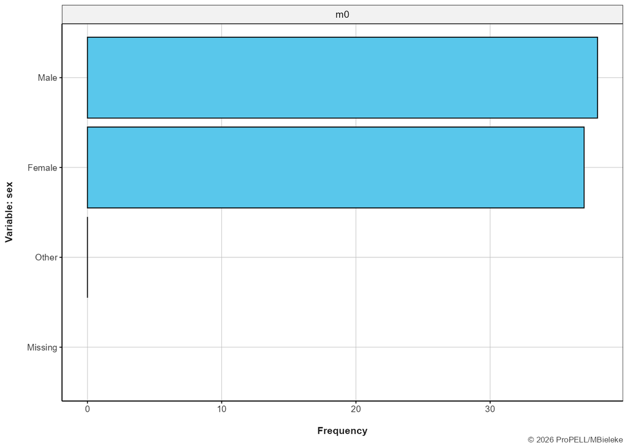

**Statistics**

| Answer | N | % | %Val |
| --- | --- | --- | --- |
| **Male** |  |  |  |
| m0 | 38 | 50.7 | 50.7 |
| **Female** |  |  |  |
| m0 | 37 | 49.3 | 49.3 |
| **Other** |  |  |  |
| m0 | 0 | 0.0 | 0.0 |

### Stage of physical activity behavior change

**Overview**

- **Variable Stem: `stage`**
- **Time Points:** m0
- **Reference:** Marcus et al. (1992)

**Details**

Please choose the statement that best describes your current physical activity behaviour.

**Distribution**

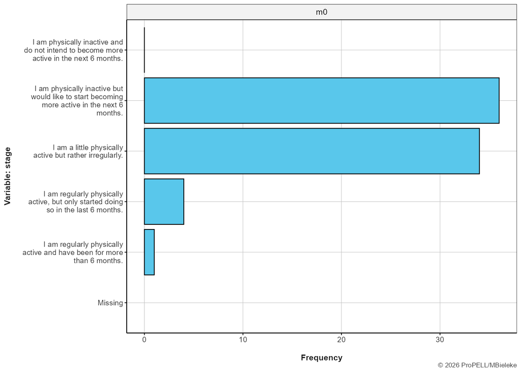

**Statistics**

| Answer | N | % | %Val |
| --- | --- | --- | --- |
| I am physically inactive and do not intend to become more active in the next 6 months. |  |  |  |
| m0 | 0 | 0.0 | 0.0 |
| I am physically inactive but would like to start becoming more active in the next 6 months. |  |  |  |
| m0 | 36 | 48.0 | 48.0 |
| I am a little physically active but rather irregularly. |  |  |  |
| m0 | 34 | 45.3 | 45.3 |
| I am regularly physically active, but only started doing so in the last 6 months. |  |  |  |
| m0 | 4 | 5.3 | 5.3 |
| I am regularly physically active and have been for more than 6 months. |  |  |  |
| m0 | 1 | 1.3 | 1.3 |

### Body weight (in kg)

**Overview**

- **Variable Stem: `weight`**
- **Time Points:** m0
- **Reference:** Custom item

**Details**

What is your body weight (in kg)?

**Distribution**

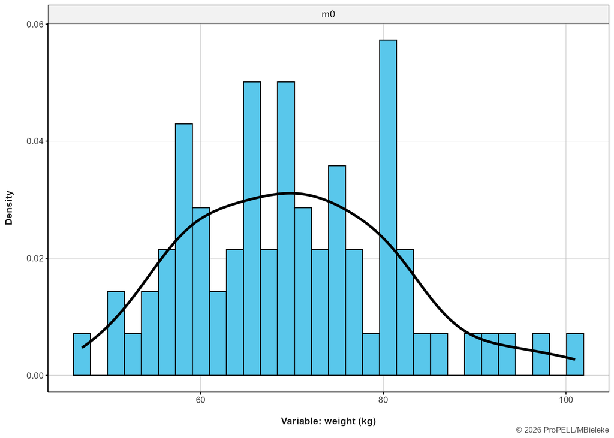

**Statistics**

| Time | N | % | %Val | Mean | SD | Min | Median | Max |
| --- | --- | --- | --- | --- | --- | --- | --- | --- |
| m0 | 75 | 75 | 100 | 70.09 | 11.43 | 47 | 70 | 101 |

# Admission Checklist

The admission checklist was part of the screening survey and is detached here to avoid any potential re-identification of participants.

- Responses to categorical checklist items are not linked to participant IDs and were randomy shuffled. Responses can still be used to characterize the sample as a whole.
- Responses to open-ended items are not included are not included in the dataset. In the codebook, we provide the original item text and response statistics.

### No overall Screening score is computed

**Overview**

- **Variable Stem: `check`**
- **Time Points:** m0
- **Reference:** Custom scale

**Note:** De-identification note: All identifiers were removed and records were shuffled in a separate dataset.

**Details**

In this part of the screening, we ask you for health-related information. Even if the connection to health is not immediately apparent for all questions, this information is important to determine whether you can participate in the measurement procedures of the ProPELL study. It is therefore important that you answer all questions thoroughly and truthfully. For some questions, if you answer “yes,” you will be asked to provide additional details. Please provide these details as precisely as possible.

| Variable | Label | Prompt |
| --- | --- | --- |
| check01 | Mental disorder status | Are you currently suffering from a mental disorder? |
| check02 | Physical illness status | Are you currently suffering from an acute physical illness? |
| check03 | Chronic illness status | Do you suffer from a chronic illness? |
| check04 | History of neurological disorder | Do you suffer from a neurological disorder? (e.g. epilepsy, stroke, Parkinson’s disease) |
| check05 | History of endocrinological or metabolic disorder | Have you been diagnosed with an endocrinological or metabolic disorder? (e.g. over- or underactive thyroid, diabetes) |
| check06 | History of Hepatitis B/C, HIV, or Cancer | Have you been diagnosed with hepatitis B, hepatitis C, HIV or cancer? |
| check07 | History of heart or circulatory disease | Have you been diagnosed with a heart/circulatory disease? (e.g. aortic stenosis, mitral stenosis, cardiomyopathies, malignant or exercise-induced arrhythmias, syncope on exertion, intracardiac shunt, … |
| check08 | Autoimmune disease status | Do you suffer from an autoimmune disease? |
| check09 | Claustrophobia status | Do you suffer from claustrophobia? |
| check10 | History of traumatic brain injury | Have you ever had a traumatic brain injury (concussion) with loss of consciousness? |
| check11 | Tinnitus status | Do you suffer from tinnitus? |
| check12 | Bone fracture status | Did you have a bone fracture in the last year? |
| check13 | Lower extremity injury status | Have you had a severe injury to the lower extremities in the last 6 months? |
| check14 | Radiotherapy status | Are you currently receiving radiotherapy? |
| check15 | Long-term glucocorticoid therapy status | Are you currently undergoing long-term therapy with glucocorticoids? |
| check16 | Presence of active implants | Do you have a pacemaker, an implanted medication pump, other implants or other electromedical devices? (e.g. insulin pump, neurostimulator, shunt, artificial stoma with magnetic closure, artificial he… |
| check17 | Presence of metallic/conductive foreign bodies or passive implants | Are there possibly metallic and electrically conductive foreign bodies or implants in your body as a result of accidents or operations? (e.g. metal prosthesis, cochlear implant, inner ear prosthesis, … |
| check18 | Tattoo status | Do you have tattoos? |
| check19 | Presence of permanent makeup or cosmetic eyelid procedures | Do you have permanent makeup (or have you had cosmetic eyelid procedures)? |
| check20 | History of heart, head, or brain surgery | Have you ever had surgery on your heart, head or brain? |
| check21 | Presence of metallic dental prostheses | Do you have metallic dental prostheses? For example retainers (wire behind the teeth), fixed braces, bridges, implants, etc. |
| check22 | Medication status | Are you currently taking any medication? |
| check23 | COVID-19 vaccination status | Are you vaccinated against COVID-19? |
| check24 | Intrauterine device status | Do you have an intrauterine device (“coil” / “IUD”)? |
| check25 | Possibility of current pregnancy | Is there a possibility that you are pregnant? |
| check26 | Sports club membership status | Are you a member of a sports club? |
| check27 | Non-club sports activity status | Do you practice any sport outside of a club? (e.g. privately in a group or alone, as part of commercial offers such as fitness studios or dance schools, health insurance programmes, company, trainee o… |

**Distribution**

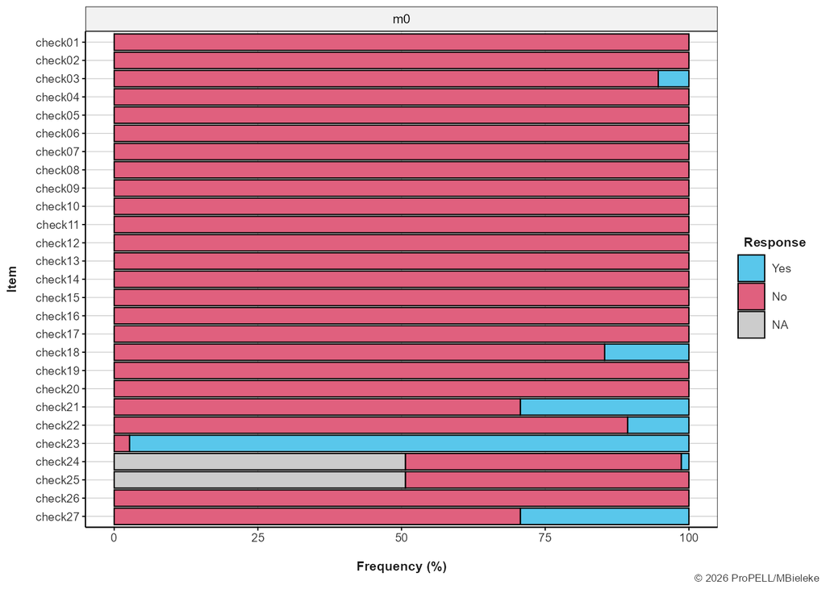

**Statistics**

| Variable | #Yes | %Yes | %Val Yes | #No | %No | %Val No | #Miss | %Miss |
| --- | --- | --- | --- | --- | --- | --- | --- | --- |
| **check01** |  |  |  |  |  |  |  |  |
| m0 | 0 | 0.0 | 0.0 | 75 | 100.0 | 100.0 | 0 | 0.0 |
| **check02** |  |  |  |  |  |  |  |  |
| m0 | 0 | 0.0 | 0.0 | 75 | 100.0 | 100.0 | 0 | 0.0 |
| **check03** |  |  |  |  |  |  |  |  |
| m0 | 4 | 5.3 | 5.3 | 71 | 94.7 | 94.7 | 0 | 0.0 |
| **check04** |  |  |  |  |  |  |  |  |
| m0 | 0 | 0.0 | 0.0 | 75 | 100.0 | 100.0 | 0 | 0.0 |
| **check05** |  |  |  |  |  |  |  |  |
| m0 | 0 | 0.0 | 0.0 | 75 | 100.0 | 100.0 | 0 | 0.0 |
| **check06** |  |  |  |  |  |  |  |  |
| m0 | 0 | 0.0 | 0.0 | 75 | 100.0 | 100.0 | 0 | 0.0 |
| **check07** |  |  |  |  |  |  |  |  |
| m0 | 0 | 0.0 | 0.0 | 75 | 100.0 | 100.0 | 0 | 0.0 |
| **check08** |  |  |  |  |  |  |  |  |
| m0 | 0 | 0.0 | 0.0 | 75 | 100.0 | 100.0 | 0 | 0.0 |
| **check09** |  |  |  |  |  |  |  |  |
| m0 | 0 | 0.0 | 0.0 | 75 | 100.0 | 100.0 | 0 | 0.0 |
| **check10** |  |  |  |  |  |  |  |  |
| m0 | 0 | 0.0 | 0.0 | 75 | 100.0 | 100.0 | 0 | 0.0 |
| **check11** |  |  |  |  |  |  |  |  |
| m0 | 0 | 0.0 | 0.0 | 75 | 100.0 | 100.0 | 0 | 0.0 |
| **check12** |  |  |  |  |  |  |  |  |
| m0 | 0 | 0.0 | 0.0 | 75 | 100.0 | 100.0 | 0 | 0.0 |
| **check13** |  |  |  |  |  |  |  |  |
| m0 | 0 | 0.0 | 0.0 | 75 | 100.0 | 100.0 | 0 | 0.0 |
| **check14** |  |  |  |  |  |  |  |  |
| m0 | 0 | 0.0 | 0.0 | 75 | 100.0 | 100.0 | 0 | 0.0 |
| **check15** |  |  |  |  |  |  |  |  |
| m0 | 0 | 0.0 | 0.0 | 75 | 100.0 | 100.0 | 0 | 0.0 |
| **check16** |  |  |  |  |  |  |  |  |
| m0 | 0 | 0.0 | 0.0 | 75 | 100.0 | 100.0 | 0 | 0.0 |
| **check17** |  |  |  |  |  |  |  |  |
| m0 | 0 | 0.0 | 0.0 | 75 | 100.0 | 100.0 | 0 | 0.0 |
| **check18** |  |  |  |  |  |  |  |  |
| m0 | 11 | 14.7 | 14.7 | 64 | 85.3 | 85.3 | 0 | 0.0 |
| **check19** |  |  |  |  |  |  |  |  |
| m0 | 0 | 0.0 | 0.0 | 75 | 100.0 | 100.0 | 0 | 0.0 |
| **check20** |  |  |  |  |  |  |  |  |
| m0 | 0 | 0.0 | 0.0 | 75 | 100.0 | 100.0 | 0 | 0.0 |
| **check21** |  |  |  |  |  |  |  |  |
| m0 | 22 | 29.3 | 29.3 | 53 | 70.7 | 70.7 | 0 | 0.0 |
| **check22** |  |  |  |  |  |  |  |  |
| m0 | 8 | 10.7 | 10.7 | 67 | 89.3 | 89.3 | 0 | 0.0 |
| **check23** |  |  |  |  |  |  |  |  |
| m0 | 73 | 97.3 | 97.3 | 2 | 2.7 | 2.7 | 0 | 0.0 |
| **check24** |  |  |  |  |  |  |  |  |
| m0 | 1 | 1.3 | 1.3 | 36 | 48.0 | 48.0 | 38 | 50.7 |
| **check25** |  |  |  |  |  |  |  |  |
| m0 | 0 | 0.0 | 0.0 | 37 | 49.3 | 49.3 | 38 | 50.7 |
| **check26** |  |  |  |  |  |  |  |  |
| m0 | 0 | 0.0 | 0.0 | 75 | 100.0 | 100.0 | 0 | 0.0 |
| **check27** |  |  |  |  |  |  |  |  |
| m0 | 22 | 29.3 | 29.3 | 53 | 70.7 | 70.7 | 0 | 0.0 |

# Trait Surveys

### No overall AEQ-SE score is computed

**Overview**

- **Variable Stem: `aeq`**
- **Time Points:** m1, m2, m3
- **Reference:** Bieleke et al. (2023)

**Details**

**Items**

**Directions**: The following questions examine your emotional experiences during sport and exercise. They are organized into three blocks—your emotions before, during, and after sport and exercise. Please first recall some typical situations in which you were physically active before answering the questions. Here, sport is defined as any form of physical activity performed for its own sake; that is, sport is performed for the purpose of the physical activity itself. This includes both competitive sport and recreational sport. The physical activity is goal-directed. The goals pursued through sport can vary widely, for example striving to improve one’s body or abilities, the desire to improve health, comparing one’s performance with oneself or others in competition, social motives, etc. There are also many different contexts in which sport can take place: outdoors (e.g., jogging or on a soccer field), in a fitness studio, in a yoga studio, alone or with others, etc. Typical physical characteristics during sport may include sweating, accelerated breathing, a faster heartbeat, or muscle fatigue. As diverse as the forms of sport can be, so too are the terms used to describe physical activity in this context. In the following questions, different terms such as “sport,” “training,” or “workout” are used. These terms should be considered synonymous.

- **Before exercise.** Exercise can evoke different emotions. This part of the questionnaire refers to emotions you may experience BEFORE an exercise session. Please read each statement carefully and, using the statements below, indicate how you typically feel before an exercise session.
- **During exercise.** This part of the questionnaire refers to emotions you may experience DURING an exercise session. Using the statements below, please indicate how you typically feel during an exercise session.
- **After exercise.** This part of the questionnaire refers to emotions you may experience AFTER an exercise session. Using the statements below, please indicate how you typically feel after an exercise session.

| Variable | Scale | Prompt |
| --- | --- | --- |
| aeq01 | Enjoyment | I get excited about doing my workout. |
| aeq02 | Enjoyment | I look forward to doing my workout. |
| aeq03 | Enjoyment | Before starting to do sports, I am eager to get going. |
| aeq04 | Hope | When starting to exercise I am full of hope. |
| aeq05 | Hope | I am full of hope that I will excel at my workout. |
| aeq06 | Hope | I am hopeful that I will perform well at my workout. |
| aeq07 | Hope | I have great hope that my abilities will be sufficient. |
| aeq08 | Relaxation | I feel relaxed because I know I will be successful. |
| aeq09 | Relaxation | The thought of succeeding makes me feel relaxed. |
| aeq10 | Relaxation | I feel relaxed because I know I will succeed even if it gets difficult. |
| aeq11 | Relaxation | I feel relaxed because I anticipate mastering the demands of this training session. |
| aeq12 | Anger | I get angry when I have to do my workout. |
| aeq13 | Anger | I get angry about the amount of training I need to do. |
| aeq14 | Anxiety | Thinking about sport makes me feel uneasy. |
| aeq15 | Anxiety | I feel scared. |
| aeq16 | Anxiety | I get tense when I start to exercise. |
| aeq17 | Anxiety | Before demanding elements in my workout I feel nervous and uneasy. |
| aeq18 | Anxiety | I feel panicky before completing demanding workout elements. |
| aeq19 | Anxiety | I worry that my training might be too difficult. |
| aeq20 | Anxiety | I worry that I might not be able to cope with all the training. |
| aeq21 | Anxiety | I worry that I might fail at my training. |
| aeq22 | Anxiety | When I think about my workout, I feel queasy. |
| aeq23 | Anxiety | Before a demanding workout I feel sick to my stomach. |
| aeq24 | Hopelessness | I feel hopeless. |
| aeq25 | Hopelessness | The thought of the demands of my workout makes me feel hopeless. |
| aeq26 | Hopelessness | I worry because my abilities are not sufficient for doing this sport. |
| aeq27 | Hopelessness | Even before starting to exercise, I am resigned to the fact that I won’t be able to meet the demands of the training. |
| aeq28 | Hopelessness | I have lost all hope in completing the workout successfully. |
| aeq29 | Hopelessness | My hopelessness steals all my energy. |
| aeq30 | Enjoyment | I enjoy doing my workout. |

[output cut: 64 more lines]

Note. Variables with * have been reverse-coded

**Scale**

| Variable | Description |
| --- | --- |
| aeq | No overall AEQ-SE score is computed |
| aeqang | Mean score of Anger items |
| aeqanx | Mean score of Anxiety items |
| aeqbor | Mean score of Boredom items |
| aeqdis | Mean score of Disppointment items |
| aeqhop | Mean score of Hope items |
| aeqhpl | Mean score of Hopelenessness items |
| aeqjoy | Mean score of Enjoyment items |
| aeqpri | Mean score of Pride items |
| aeqrel | Mean score of Relief items |
| aeqrlx | Mean score of Relaxation items |
| aeqsha | Mean score of Shame items |

**Distribution**

**Items**

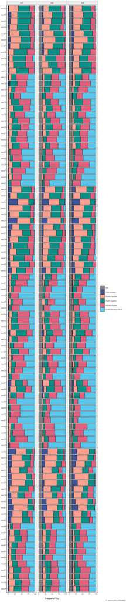

**Scale**

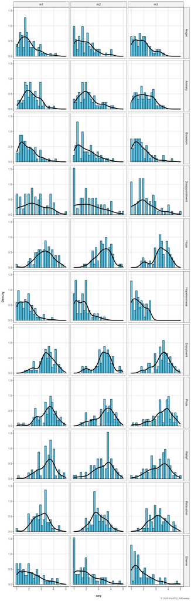

**Statistics**

**Items**

| Variable | N | #Valid | %Valid | Mean | SD | Min | Median | Max |
| --- | --- | --- | --- | --- | --- | --- | --- | --- |
| **aeq01** |  |  |  |  |  |  |  |  |
| m1 | 75 | 74 | 98.67 | 3.15 | 0.82 | 1 | 3.0 | 5 |
| m2 | 75 | 66 | 88.00 | 3.11 | 0.88 | 1 | 3.0 | 5 |
| m3 | 75 | 67 | 89.33 | 3.21 | 0.93 | 1 | 3.0 | 5 |
| **aeq02** |  |  |  |  |  |  |  |  |
| m1 | 75 | 74 | 98.67 | 3.27 | 0.86 | 1 | 3.0 | 5 |
| m2 | 75 | 66 | 88.00 | 3.32 | 0.84 | 1 | 3.0 | 5 |
| m3 | 75 | 67 | 89.33 | 3.36 | 0.81 | 1 | 3.0 | 5 |
| **aeq03** |  |  |  |  |  |  |  |  |
| m1 | 75 | 74 | 98.67 | 3.22 | 0.86 | 1 | 3.0 | 5 |
| m2 | 75 | 66 | 88.00 | 3.27 | 0.90 | 1 | 3.0 | 5 |
| m3 | 75 | 67 | 89.33 | 3.22 | 0.92 | 1 | 3.0 | 5 |
| **aeq04** |  |  |  |  |  |  |  |  |
| m1 | 75 | 74 | 98.67 | 3.08 | 0.90 | 1 | 3.0 | 5 |
| m2 | 75 | 66 | 88.00 | 3.05 | 0.87 | 1 | 3.0 | 4 |
| m3 | 75 | 67 | 89.33 | 3.13 | 0.89 | 1 | 3.0 | 5 |
| **aeq05** |  |  |  |  |  |  |  |  |
| m1 | 75 | 74 | 98.67 | 3.23 | 0.87 | 1 | 3.0 | 5 |
| m2 | 75 | 66 | 88.00 | 3.45 | 0.77 | 2 | 3.5 | 5 |
| m3 | 75 | 67 | 89.33 | 3.43 | 0.86 | 2 | 3.0 | 5 |
| **aeq06** |  |  |  |  |  |  |  |  |
| m1 | 75 | 74 | 98.67 | 3.34 | 0.90 | 1 | 3.0 | 5 |
| m2 | 75 | 66 | 88.00 | 3.59 | 0.63 | 2 | 4.0 | 5 |
| m3 | 75 | 67 | 89.33 | 3.60 | 0.84 | 1 | 4.0 | 5 |
| **aeq07** |  |  |  |  |  |  |  |  |
| m1 | 75 | 74 | 98.67 | 3.26 | 0.91 | 1 | 3.0 | 5 |
| m2 | 75 | 66 | 88.00 | 3.39 | 0.87 | 1 | 3.0 | 5 |
| m3 | 75 | 67 | 89.33 | 3.39 | 0.82 | 1 | 3.0 | 5 |
| **aeq08** |  |  |  |  |  |  |  |  |
| m1 | 75 | 74 | 98.67 | 2.89 | 0.73 | 1 | 3.0 | 4 |

[output cut: 346 more lines]

**Scale**

[output not shown]

### Overall AMBS mean score

**Overview**

- **Variable Stem: `ambs`**
- **Time Points:** m1
- **Reference:** Hirschi & Spurk (2021)

**Details**

**Items**

**Directions**: Please read the following statements and indicate how strongly you agree with them.

| Variable | Prompt |
| --- | --- |
| ambs01 | I am ambitious. |
| ambs02 | I strive for success. |
| ambs03 | I have challenging goals. |
| ambs04 | For me it is very important to achieve outstanding results in my life. |
| ambs05 | For me it is very important to accomplish great things. |

Note. Variables with * have been reverse-coded

**Scale**

| Variable | Description |
| --- | --- |
| ambs | Overall AMBS mean score |

**Distribution**

**Items**

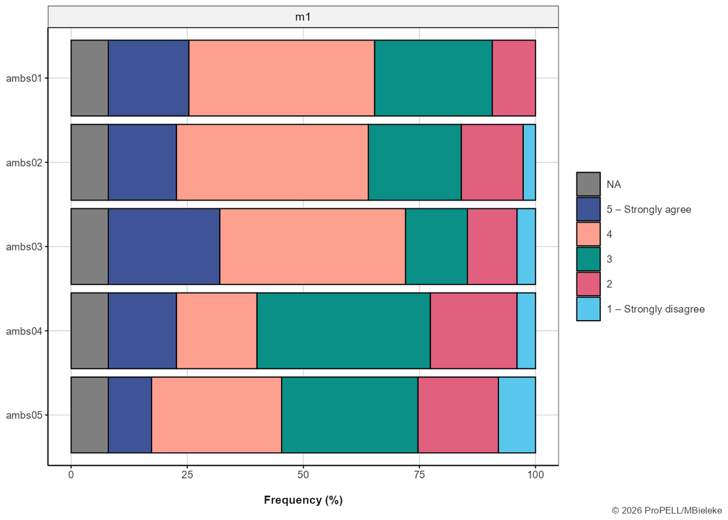

**Scale**

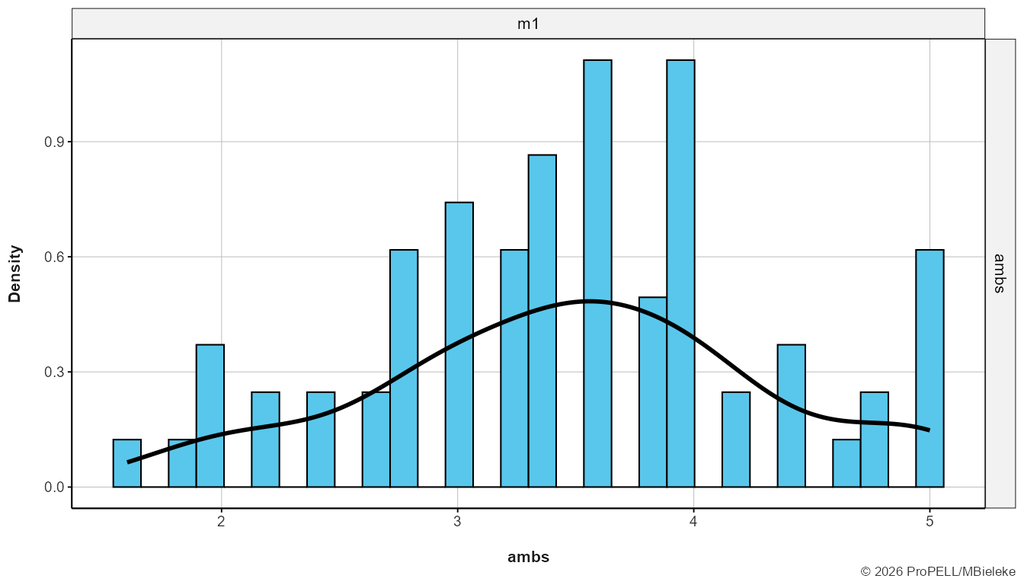

**Statistics**

**Items**

| Variable | N | #Valid | %Valid | Mean | SD | Min | Median | Max |
| --- | --- | --- | --- | --- | --- | --- | --- | --- |
| **ambs01** |  |  |  |  |  |  |  |  |
| m1 | 75 | 69 | 92 | 3.71 | 0.89 | 2 | 4 | 5 |
| **ambs02** |  |  |  |  |  |  |  |  |
| m1 | 75 | 69 | 92 | 3.57 | 1.02 | 1 | 4 | 5 |
| **ambs03** |  |  |  |  |  |  |  |  |
| m1 | 75 | 69 | 92 | 3.75 | 1.10 | 1 | 4 | 5 |
| **ambs04** |  |  |  |  |  |  |  |  |
| m1 | 75 | 69 | 92 | 3.22 | 1.08 | 1 | 3 | 5 |
| **ambs05** |  |  |  |  |  |  |  |  |
| m1 | 75 | 69 | 92 | 3.14 | 1.12 | 1 | 3 | 5 |

**Scale**

| Variable | N | #Valid | %Valid | SD | Mean | Min | Median | Max | #Items | Alpha |
| --- | --- | --- | --- | --- | --- | --- | --- | --- | --- | --- |
| **ambs** |  |  |  |  |  |  |  |  |  |  |
| m1 | 75 | 69 | 92 | 0.83 | 3.48 | 1.6 | 3.6 | 5 | 5 | 0.85 |

### Overall AQoL-8D percentage score

**Overview**

- **Variable Stem: `aqol`**
- **Time Points:** m1, m2, m3
- **Reference:** Richardson et al. (2014)

**Details**

**Items**

**Directions**: Below you will find a series of statements. Please select the statement that best describes your situation over the past 7 days. Please note: These questions were developed for comparisons across different age groups (including older age). Therefore, not all statements may seem applicable to your current life situation. Nevertheless, please select the statement that fits best in each case.

| Variable | Scale | Prompt |
| --- | --- | --- |
| aqol01 | Coping | How much energy do you have to do the things you want to do? I am … |
| aqol02 | Relationships | How often do you feel socially excluded or left out? |
| aqol03 | Independent Living | How easy or difficult is it for you to get around by yourself outside your place of residence (eg. to go shopping, visiting)? |
| aqol04 | Relationships | Does your health affect your role in your community (eg. residential, sporting, church or cultural activities)? |
| aqol05 | Mental Health | How often do you feel sad? |
| aqol06 | Pain | How often do you experience serious pain? I experience it… |
| aqol07 | Self-Worth | How much confidence do you have in yourself? |
| aqol08 | Mental Health | Do you normally feel calm and tranquil or agitated? I am… |
| aqol09 | Relationships | Does your health affect your relationship with your family? |
| aqol10 | Relationships | How satisfying are your close relationships (family and friends)? |
| aqol11 | Senses | How well do you communicate with others (talking, signing, texting, being understood by others and understanding them)? |
| aqol12 | Mental Health | How often do you have trouble sleeping? |
| aqol13 | Self-Worth | How often do you feel worthless? |
| aqol14 | Mental Health | How often do you feel angry? |
| aqol15 | Independent Living | How easy or difficult is it for you to move around (using any aids or equipment you need eg a wheelchair, frame or stick)? |
| aqol16 | Mental Health | Do you ever feel like hurting yourself? |
| aqol17 | Happiness | How enthusiastic do you feel? |
| aqol18 | Mental Health | How often did you feel worried in the last seven days? |
| aqol19 | Independent Living | How difficult is it for you to wash, toilet, dress yourself, eat or care for your appearance? |
| aqol20 | Happiness | How often do you feel happy? |
| aqol21 | Coping | How much do you feel you can cope with life’s problems? |
| aqol22 | Pain | How much pain or discomfort do you experience? |
| aqol23 | Relationships | How much do you enjoy your close relationships (family and friends)? |
| aqol24 | Pain | How often does pain interfere with your usual activities? |
| aqol25 | Happiness | How often do you feel pleasure? |
| aqol26 | Self-Worth | How much of a burden do you feel you are to other people? |
| aqol27 | Happiness | How content are you with your life? |
| aqol28 | Senses | How well can you see (using your glasses or contact lenses if they are needed)? |
| aqol29 | Coping | How often do you feel in control of your life? |
| aqol30 | Independent Living | How much help do you need with jobs around your place of residence (eg preparing food, cleaning, gardening)? |
| aqol31 | Relationships | How often do you feel socially isolated? |
| aqol32 | Senses | How well can you hear (using your hearing aid if needed)? |
| aqol33 | Mental Health | How often do you feel depressed? |
| aqol34 | Relationships | How happy are you with your close and intimate relationships? |
| aqol35 | Mental Health | How often did you feel in despair in the last seven days? |

Note. Variables with * have been reverse-coded

**Scale**

| Variable | Description |
| --- | --- |
| aqol | Overall AQoL-8D percentage score |
| aqolcp | Percentage score for Coping items |
| aqolhp | Percentage score for Happiness items |
| aqolil | Percentage score for Independent Living items |
| aqolmh | Percentage score for Mental Health items |
| aqolmsd | Percentage score for Mental items |
| aqolpn | Percentage score for Pain items |
| aqolpsd | Percentage score for Physical items |
| aqolrl | Percentage score for Relationships items |
| aqolsn | Percentage score for Senses items |
| aqolsw | Percentage score for Self-Worth items |

**Distribution**

**Items**

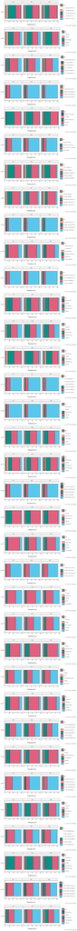

**Scale**

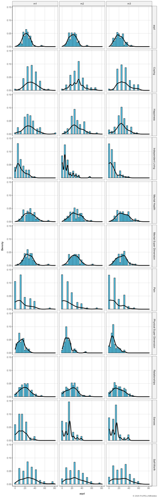

**Statistics**

**Items**

| Variable | N | #Valid | %Valid | Mean | SD | Min | Median | Max |
| --- | --- | --- | --- | --- | --- | --- | --- | --- |
| **aqol01** |  |  |  |  |  |  |  |  |
| m1 | 75 | 71 | 94.67 | 2.73 | 0.72 | 1 | 3.0 | 4 |
| m2 | 75 | 68 | 90.67 | 2.54 | 0.63 | 1 | 2.5 | 4 |
| m3 | 75 | 66 | 88.00 | 2.45 | 0.71 | 1 | 2.0 | 4 |
| **aqol02** |  |  |  |  |  |  |  |  |
| m1 | 75 | 71 | 94.67 | 2.44 | 0.89 | 1 | 2.0 | 4 |
| m2 | 75 | 68 | 90.67 | 2.35 | 0.88 | 1 | 2.0 | 4 |
| m3 | 75 | 66 | 88.00 | 2.44 | 0.73 | 1 | 2.0 | 4 |
| **aqol03** |  |  |  |  |  |  |  |  |
| m1 | 75 | 71 | 94.67 | 2.11 | 0.96 | 1 | 2.0 | 5 |
| m2 | 75 | 68 | 90.67 | 1.91 | 0.82 | 1 | 2.0 | 4 |
| m3 | 75 | 66 | 88.00 | 1.76 | 0.80 | 1 | 2.0 | 4 |
| **aqol04** |  |  |  |  |  |  |  |  |
| m1 | 75 | 71 | 94.67 | 1.28 | 0.51 | 1 | 1.0 | 3 |
| m2 | 75 | 68 | 90.67 | 1.24 | 0.60 | 1 | 1.0 | 4 |
| m3 | 75 | 66 | 88.00 | 1.12 | 0.37 | 1 | 1.0 | 3 |
| **aqol05** |  |  |  |  |  |  |  |  |
| m1 | 75 | 71 | 94.67 | 2.49 | 0.67 | 1 | 3.0 | 5 |
| m2 | 75 | 68 | 90.67 | 2.53 | 0.68 | 1 | 3.0 | 4 |
| m3 | 75 | 66 | 88.00 | 2.45 | 0.68 | 1 | 2.0 | 5 |
| **aqol06** |  |  |  |  |  |  |  |  |
| m1 | 75 | 71 | 94.67 | 1.42 | 0.60 | 1 | 1.0 | 3 |
| m2 | 75 | 68 | 90.67 | 1.29 | 0.55 | 1 | 1.0 | 3 |
| m3 | 75 | 66 | 88.00 | 1.24 | 0.50 | 1 | 1.0 | 3 |
| **aqol07** |  |  |  |  |  |  |  |  |
| m1 | 75 | 71 | 94.67 | 2.63 | 0.68 | 1 | 3.0 | 4 |
| m2 | 75 | 68 | 90.67 | 2.46 | 0.78 | 1 | 2.0 | 4 |
| m3 | 75 | 66 | 88.00 | 2.47 | 0.75 | 1 | 2.0 | 4 |
| **aqol08** |  |  |  |  |  |  |  |  |
| m1 | 75 | 71 | 94.67 | 2.38 | 0.76 | 1 | 2.0 | 4 |

[output cut: 110 more lines]

**Scale**

[output not shown]

### Overall ASQ mean score

**Overview**

- **Variable Stem: `asq`**
- **Time Points:** m1, m2, m3
- **Reference:** Riemer & Chelladurai (1998)

**Details**

**Items**

**Directions**: The following questions concern your satisfaction with your exercise goals.

| Variable | Scale | Prompt |
| --- | --- | --- |
| asq01 | Individual Performance | I am satisfied with the degree to which I achieve my athletic goals. |
| asq02 | Individual Performance | I am satisfied with my performance development in sports. |
| asq03 | Individual Performance | I find my athletic performance level satisfactory. |
| asq04 | Ability Utilization | I am satisfied with the extent to which I can use my abilities in sports. |
| asq05 | Ability Utilization | I find the opportunities to use my talents in sports satisfactory. |
| asq06 | Ability Utilization | I am satisfied with the degree to which I can realize my potential in sports. |
| asq07 | Personal Dedication | I am satisfied with the extent to which I give my best in sports. |
| asq08 | Personal Dedication | I am satisfied with my level of commitment in sports. |
| asq09 | Personal Dedication | I find my enthusiasm for sports satisfactory. |

Note. Variables with * have been reverse-coded

**Scale**

| Variable | Description |
| --- | --- |
| asq | Overall ASQ mean score |
| asqau | Mean score of Ability Utilization items |
| asqip | Mean score of Individual Performance items |
| asqpd | Mean score of Personal Dedication items |

**Distribution**

**Items**

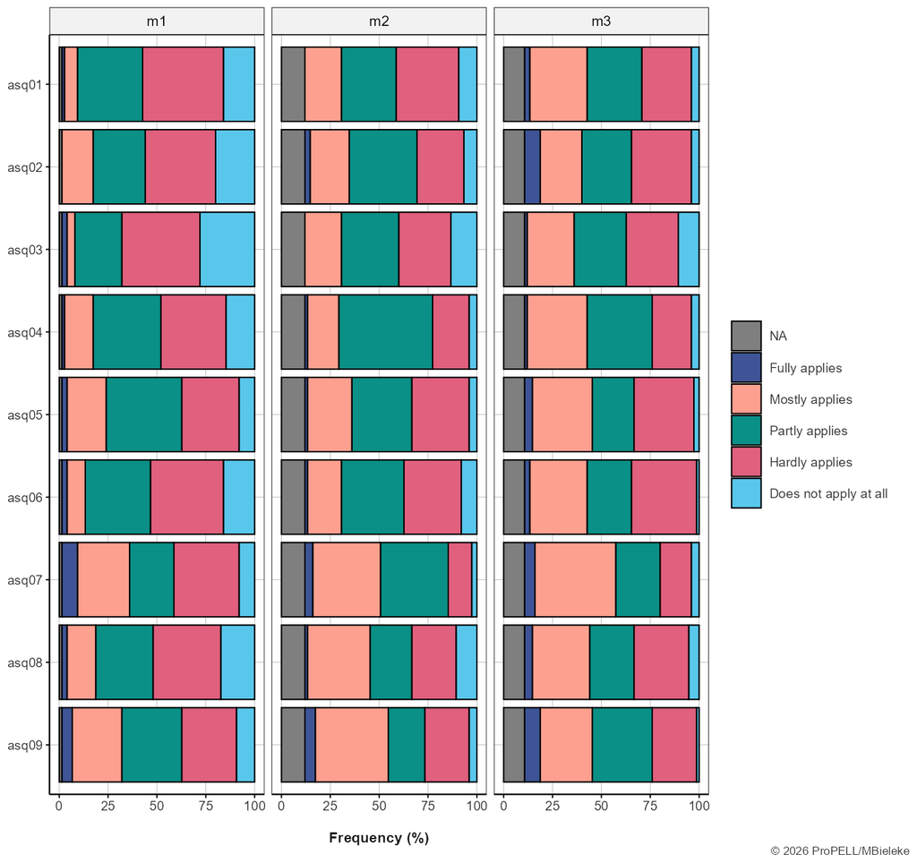

**Scale**

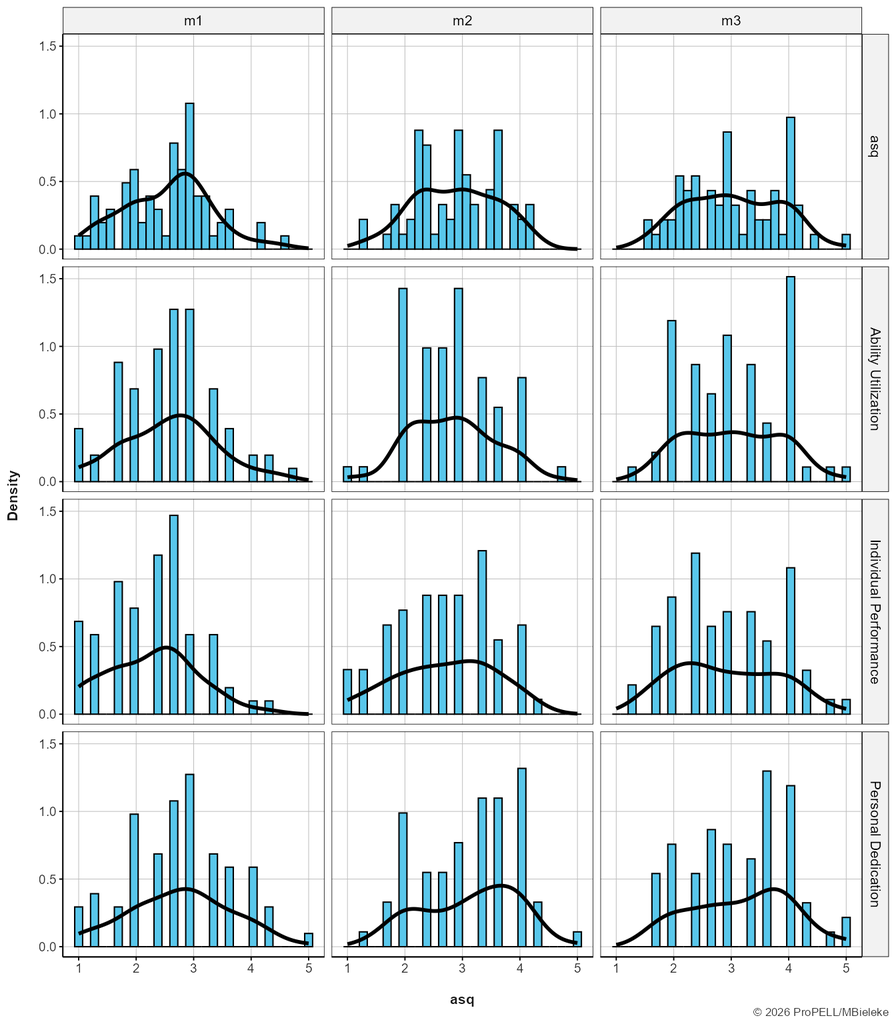

**Statistics**

**Items**

| Variable | N | #Valid | %Valid | Mean | SD | Min | Median | Max |
| --- | --- | --- | --- | --- | --- | --- | --- | --- |
| **asq01** |  |  |  |  |  |  |  |  |
| m1 | 75 | 74 | 98.67 | 2.35 | 0.88 | 1 | 2 | 5 |
| m2 | 75 | 66 | 88.00 | 2.64 | 0.94 | 1 | 3 | 4 |
| m3 | 75 | 67 | 89.33 | 3.01 | 0.96 | 1 | 3 | 5 |
| **asq02** |  |  |  |  |  |  |  |  |
| m1 | 75 | 74 | 98.67 | 2.39 | 0.99 | 1 | 2 | 4 |
| m2 | 75 | 66 | 88.00 | 2.86 | 0.96 | 1 | 3 | 5 |
| m3 | 75 | 67 | 89.33 | 2.99 | 1.07 | 1 | 3 | 5 |
| **asq03** |  |  |  |  |  |  |  |  |
| m1 | 75 | 74 | 98.67 | 2.12 | 0.96 | 1 | 2 | 5 |
| m2 | 75 | 66 | 88.00 | 2.61 | 0.99 | 1 | 3 | 4 |
| m3 | 75 | 67 | 89.33 | 2.76 | 1.03 | 1 | 3 | 5 |
| **asq04** |  |  |  |  |  |  |  |  |
| m1 | 75 | 74 | 98.67 | 2.54 | 0.97 | 1 | 3 | 5 |
| m2 | 75 | 66 | 88.00 | 2.91 | 0.80 | 1 | 3 | 5 |
| m3 | 75 | 67 | 89.33 | 3.06 | 0.90 | 1 | 3 | 5 |
| **asq05** |  |  |  |  |  |  |  |  |
| m1 | 75 | 74 | 98.67 | 2.80 | 0.95 | 1 | 3 | 5 |
| m2 | 75 | 66 | 88.00 | 2.86 | 0.91 | 1 | 3 | 5 |
| m3 | 75 | 67 | 89.33 | 3.03 | 1.00 | 1 | 3 | 5 |
| **asq06** |  |  |  |  |  |  |  |  |
| m1 | 75 | 74 | 98.67 | 2.45 | 0.97 | 1 | 2 | 5 |
| m2 | 75 | 66 | 88.00 | 2.71 | 0.94 | 1 | 3 | 5 |
| m3 | 75 | 67 | 89.33 | 2.99 | 0.95 | 1 | 3 | 5 |
| **asq07** |  |  |  |  |  |  |  |  |
| m1 | 75 | 74 | 98.67 | 2.93 | 1.13 | 1 | 3 | 5 |
| m2 | 75 | 66 | 88.00 | 3.29 | 0.87 | 1 | 3 | 5 |
| m3 | 75 | 67 | 89.33 | 3.31 | 0.99 | 1 | 4 | 5 |
| **asq08** |  |  |  |  |  |  |  |  |
| m1 | 75 | 74 | 98.67 | 2.50 | 1.04 | 1 | 2 | 5 |
| m2 | 75 | 66 | 88.00 | 2.89 | 1.08 | 1 | 3 | 5 |
| m3 | 75 | 67 | 89.33 | 2.99 | 1.04 | 1 | 3 | 5 |
| **asq09** |  |  |  |  |  |  |  |  |
| m1 | 75 | 74 | 98.67 | 2.89 | 1.07 | 1 | 3 | 5 |
| m2 | 75 | 66 | 88.00 | 3.20 | 1.04 | 1 | 3 | 5 |
| m3 | 75 | 67 | 89.33 | 3.19 | 0.97 | 1 | 3 | 5 |

**Scale**

| Variable | N | #Valid | %Valid | SD | Mean | Min | Median | Max | #Items | Alpha |
| --- | --- | --- | --- | --- | --- | --- | --- | --- | --- | --- |
| **asq** |  |  |  |  |  |  |  |  |  |  |
| m1 | 75 | 74 | 98.67 | 0.75 | 2.55 | 1.00 | 2.67 | 4.56 | 9 | 0.91 |
| m2 | 75 | 66 | 88.00 | 0.72 | 2.89 | 1.33 | 2.89 | 4.22 | 9 | 0.91 |
| m3 | 75 | 67 | 89.33 | 0.81 | 3.04 | 1.56 | 3.00 | 5.00 | 9 | 0.94 |
| **asqau** |  |  |  |  |  |  |  |  |  |  |
| m1 | 75 | 74 | 98.67 | 0.82 | 2.59 | 1.00 | 2.67 | 4.67 | 3 | 0.81 |
| m2 | 75 | 66 | 88.00 | 0.74 | 2.83 | 1.00 | 2.83 | 4.67 | 3 | 0.79 |
| m3 | 75 | 67 | 89.33 | 0.84 | 3.02 | 1.33 | 3.00 | 5.00 | 3 | 0.86 |
| **asqip** |  |  |  |  |  |  |  |  |  |  |
| m1 | 75 | 74 | 98.67 | 0.78 | 2.29 | 1.00 | 2.33 | 4.33 | 3 | 0.76 |
| m2 | 75 | 66 | 88.00 | 0.86 | 2.70 | 1.00 | 2.67 | 4.33 | 3 | 0.87 |
| m3 | 75 | 67 | 89.33 | 0.91 | 2.92 | 1.33 | 3.00 | 5.00 | 3 | 0.87 |
| **asqpd** |  |  |  |  |  |  |  |  |  |  |
| m1 | 75 | 74 | 98.67 | 0.89 | 2.77 | 1.00 | 2.67 | 5.00 | 3 | 0.77 |
| m2 | 75 | 66 | 88.00 | 0.84 | 3.13 | 1.33 | 3.33 | 5.00 | 3 | 0.78 |
| m3 | 75 | 67 | 89.33 | 0.87 | 3.16 | 1.67 | 3.33 | 5.00 | 3 | 0.84 |

### Overall BAES mean score

**Overview**

- **Variable Stem: `baes`**
- **Time Points:** m1, m2, m3
- **Reference:** Bieleke et al. (2022)

**Details**

**Items**

**Directions**: The following statements refer to how you deal with boredom. Please read each statement and indicate how much it applies to you.

| Variable | Prompt |
| --- | --- |
| baes01 | I’ll do anything to avoid feeling bored. |
| baes02 | I do all I can to avoid getting into boring situations. |
| baes03 | I’ll do anything to stop feeling bored. |
| baes04 | When I feel bored, I must do something about it immediately. |

Note. Variables with * have been reverse-coded

**Scale**

| Variable | Description |
| --- | --- |
| baes | Overall BAES mean score |

**Distribution**

**Items**

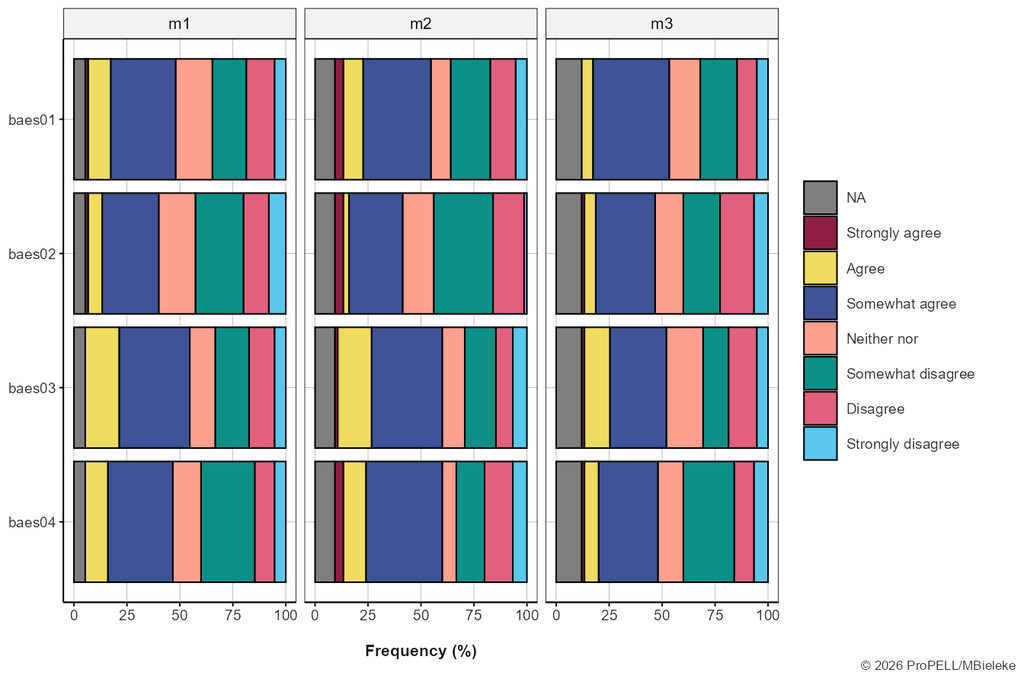

**Scale**

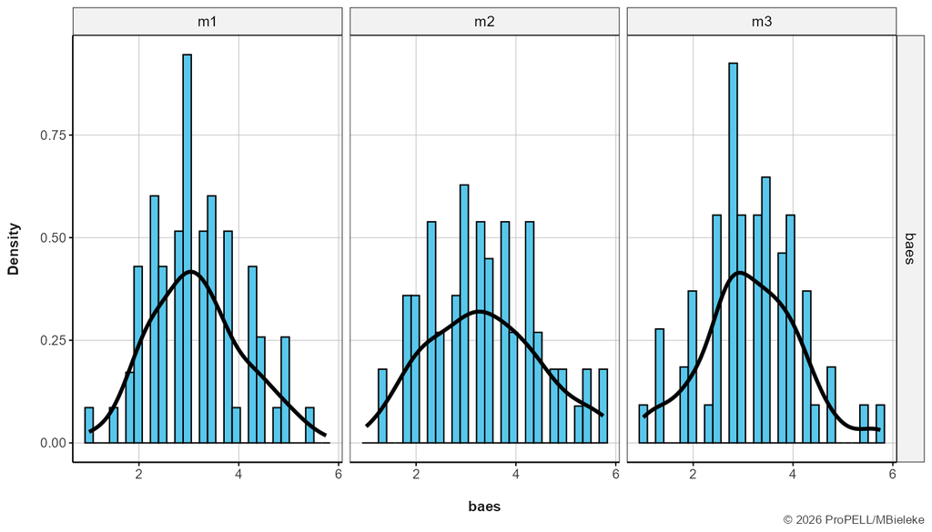

**Statistics**

**Items**

| Variable | N | #Valid | %Valid | Mean | SD | Min | Median | Max |
| --- | --- | --- | --- | --- | --- | --- | --- | --- |
| **baes01** |  |  |  |  |  |  |  |  |
| m1 | 75 | 71 | 94.67 | 3.97 | 1.47 | 1 | 4.0 | 7 |
| m2 | 75 | 68 | 90.67 | 4.04 | 1.57 | 1 | 4.5 | 7 |
| m3 | 75 | 66 | 88.00 | 3.94 | 1.36 | 1 | 4.0 | 6 |
| **baes02** |  |  |  |  |  |  |  |  |
| m1 | 75 | 71 | 94.67 | 3.72 | 1.47 | 1 | 4.0 | 7 |
| m2 | 75 | 68 | 90.67 | 3.79 | 1.37 | 1 | 4.0 | 7 |
| m3 | 75 | 66 | 88.00 | 3.70 | 1.50 | 1 | 4.0 | 7 |
| **baes03** |  |  |  |  |  |  |  |  |
| m1 | 75 | 71 | 94.67 | 4.10 | 1.49 | 1 | 5.0 | 6 |
| m2 | 75 | 68 | 90.67 | 4.21 | 1.54 | 1 | 5.0 | 7 |
| m3 | 75 | 66 | 88.00 | 4.00 | 1.52 | 1 | 4.0 | 7 |
| **baes04** |  |  |  |  |  |  |  |  |
| m1 | 75 | 71 | 94.67 | 3.92 | 1.40 | 1 | 4.0 | 6 |
| m2 | 75 | 68 | 90.67 | 4.10 | 1.64 | 1 | 5.0 | 7 |
| m3 | 75 | 66 | 88.00 | 3.80 | 1.46 | 1 | 4.0 | 7 |

**Scale**

| Variable | N | #Valid | %Valid | SD | Mean | Min | Median | Max | #Items | Alpha |
| --- | --- | --- | --- | --- | --- | --- | --- | --- | --- | --- |
| **baes** |  |  |  |  |  |  |  |  |  |  |
| m1 | 75 | 71 | 94.67 | 0.93 | 3.16 | 1.00 | 3.00 | 5.50 | 4 | 0.89 |
| m2 | 75 | 68 | 90.67 | 1.11 | 3.36 | 1.25 | 3.25 | 5.75 | 4 | 0.92 |
| m3 | 75 | 66 | 88.00 | 0.97 | 3.15 | 1.00 | 3.12 | 5.75 | 4 | 0.90 |

### Participant’s year of birth

**Overview**

- **Variable Stem: `birthyear`**
- **Time Points:** m1
- **Reference:** Custom item

**Details**

What is your year of birth?

**Distribution**

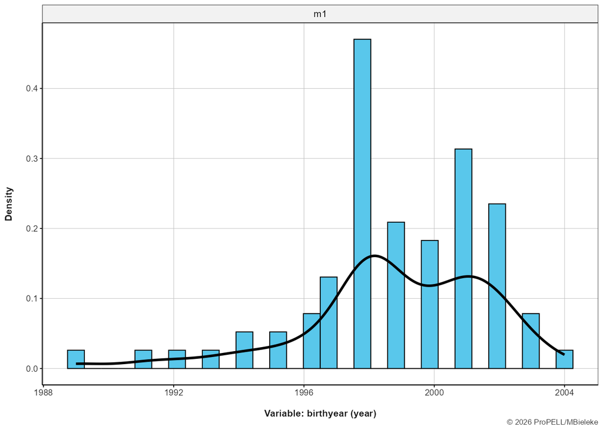

**Statistics**

| Time | N | % | %Val | Mean | SD | Min | Median | Max |
| --- | --- | --- | --- | --- | --- | --- | --- | --- |
| m1 | 75 | 74 | 98.67 | 1998.85 | 2.87 | 1989 | 1999 | 2004 |

### No overall BPNSFS score is computed

**Overview**

- **Variable Stem: `bpnsfs`**
- **Time Points:** m1, m2, m3
- **Reference:** Monteiro et al. (2020)

**Details**

**Items**

| Variable | Scale | Prompt |
| --- | --- | --- |
| bpnsfs01 | Competence Satisfaction | When engaging in sports and physical activity ... I am convinced that I am good at the exercises. |
| bpnsfs02 | Competence Frustration | When engaging in sports and physical activity ... I do not feel confident in my abilities. |

Note. Variables with * have been reverse-coded

**Scale**

| Variable | Description |
| --- | --- |
| bpnsfs | No overall BPNSFS score is computed |

**Distribution**

**Items**

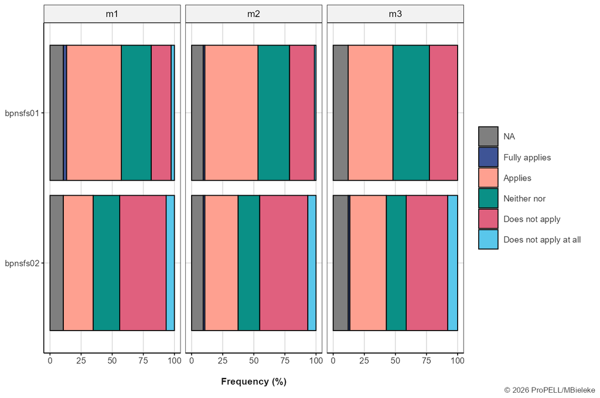

**Scale**

No overall score is available for this scale.

**Statistics**

**Items**

| Variable | N | #Valid | %Valid | Mean | SD | Min | Median | Max |
| --- | --- | --- | --- | --- | --- | --- | --- | --- |
| **bpnsfs01** |  |  |  |  |  |  |  |  |
| m1 | 75 | 67 | 89.33 | 3.31 | 0.91 | 1 | 4.0 | 5 |
| m2 | 75 | 68 | 90.67 | 3.25 | 0.87 | 1 | 3.0 | 5 |
| m3 | 75 | 66 | 88.00 | 3.15 | 0.81 | 2 | 3.0 | 4 |
| **bpnsfs02** |  |  |  |  |  |  |  |  |
| m1 | 75 | 67 | 89.33 | 2.70 | 0.95 | 1 | 3.0 | 4 |
| m2 | 75 | 68 | 90.67 | 2.75 | 1.01 | 1 | 2.5 | 5 |
| m3 | 75 | 66 | 88.00 | 2.80 | 1.06 | 1 | 3.0 | 5 |

**Scale**

No overall score is available for this scale.

### Overall BSCS mean score

**Overview**

- **Variable Stem: `bscs`**
- **Time Points:** m1, m2, m3
- **Reference:** Tangney et al. (2004)

**Details**

**Items**

**Directions**: Using the scale provided, please indicate the extent to which each of the following statements reflects your typical character, in your opinion.

| Variable | Prompt |
| --- | --- |
| bscs01 | I am good at resisting temptation. |
| bscs02* | I have a hard time breaking bad habits. |
| bscs03* | I am lazy. |
| bscs04* | I say inappropriate things. |
| bscs05* | I do certain things that are bad for me, if they are fun. |
| bscs06* | I refuse things that are bad for me. |
| bscs07* | I wish I had more self-discipline. |
| bscs08* | People would say that I have iron self-discipline. |
| bscs09 | Pleasure and fun sometimes keep me from getting work done. |
| bscs10* | I have trouble concentrating. |
| bscs11* | I am able to work effectively toward long-term goals. |
| bscs12 | Sometimes I can't stop myself from doing something, even if I know it is wrong. |
| bscs13 | I often act without thinking through all the alternatives. |

Note. Variables with * have been reverse-coded

**Scale**

| Variable | Description |
| --- | --- |
| bscs | Overall BSCS mean score |

**Distribution**

**Items**

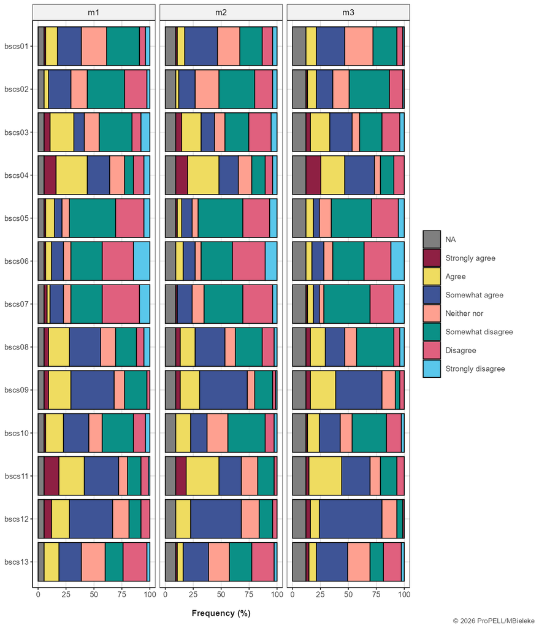

**Scale**

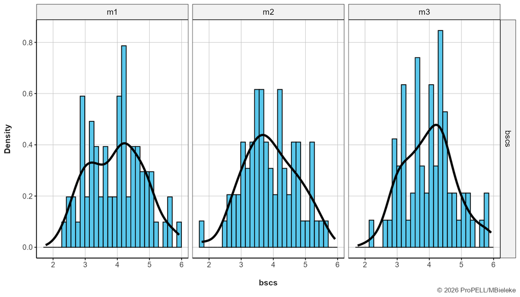

**Statistics**

**Items**

| Variable | N | #Valid | %Valid | Mean | SD | Min | Median | Max |
| --- | --- | --- | --- | --- | --- | --- | --- | --- |
| **bscs01** |  |  |  |  |  |  |  |  |
| m1 | 75 | 71 | 94.67 | 3.94 | 1.32 | 1 | 4 | 7 |
| m2 | 75 | 68 | 90.67 | 3.96 | 1.34 | 1 | 4 | 7 |
| m3 | 75 | 66 | 88.00 | 4.09 | 1.16 | 1 | 4 | 6 |
| **bscs02** |  |  |  |  |  |  |  |  |
| m1 | 75 | 71 | 94.67 | 3.44 | 1.24 | 1 | 3 | 6 |
| m2 | 75 | 68 | 90.67 | 3.38 | 1.17 | 1 | 3 | 6 |
| m3 | 75 | 66 | 88.00 | 3.67 | 1.29 | 1 | 3 | 7 |
| **bscs03** |  |  |  |  |  |  |  |  |
| m1 | 75 | 71 | 94.67 | 3.99 | 1.72 | 1 | 4 | 7 |
| m2 | 75 | 68 | 90.67 | 3.84 | 1.76 | 1 | 3 | 7 |
| m3 | 75 | 66 | 88.00 | 4.03 | 1.68 | 1 | 4 | 7 |
| **bscs04** |  |  |  |  |  |  |  |  |
| m1 | 75 | 71 | 94.67 | 4.69 | 1.72 | 1 | 5 | 7 |
| m2 | 75 | 68 | 90.67 | 4.75 | 1.67 | 1 | 5 | 7 |
| m3 | 75 | 66 | 88.00 | 4.89 | 1.56 | 2 | 5 | 7 |
| **bscs05** |  |  |  |  |  |  |  |  |
| m1 | 75 | 71 | 94.67 | 3.14 | 1.36 | 1 | 3 | 7 |
| m2 | 75 | 68 | 90.67 | 3.04 | 1.30 | 1 | 3 | 7 |
| m3 | 75 | 66 | 88.00 | 3.08 | 1.26 | 1 | 3 | 6 |
| **bscs06** |  |  |  |  |  |  |  |  |
| m1 | 75 | 71 | 94.67 | 2.92 | 1.48 | 1 | 3 | 7 |
| m2 | 75 | 68 | 90.67 | 2.96 | 1.42 | 1 | 3 | 6 |
| m3 | 75 | 66 | 88.00 | 2.97 | 1.40 | 1 | 3 | 6 |
| **bscs07** |  |  |  |  |  |  |  |  |
| m1 | 75 | 71 | 94.67 | 2.97 | 1.43 | 1 | 3 | 7 |
| m2 | 75 | 68 | 90.67 | 3.09 | 1.19 | 1 | 3 | 7 |
| m3 | 75 | 66 | 88.00 | 2.95 | 1.33 | 1 | 3 | 7 |
| **bscs08** |  |  |  |  |  |  |  |  |
| m1 | 75 | 71 | 94.67 | 4.31 | 1.55 | 1 | 5 | 7 |
| m2 | 75 | 68 | 90.67 | 4.13 | 1.52 | 1 | 4 | 7 |
| m3 | 75 | 66 | 88.00 | 4.00 | 1.51 | 1 | 4 | 7 |
| **bscs09** |  |  |  |  |  |  |  |  |
| m1 | 75 | 71 | 94.67 | 4.69 | 1.23 | 2 | 5 | 7 |
| m2 | 75 | 68 | 90.67 | 4.71 | 1.26 | 1 | 5 | 7 |
| m3 | 75 | 66 | 88.00 | 4.98 | 1.09 | 2 | 5 | 7 |
| **bscs10** |  |  |  |  |  |  |  |  |
| m1 | 75 | 71 | 94.67 | 3.97 | 1.48 | 1 | 4 | 7 |
| m2 | 75 | 68 | 90.67 | 3.82 | 1.32 | 1 | 4 | 6 |
| m3 | 75 | 66 | 88.00 | 3.76 | 1.43 | 1 | 3 | 7 |
| **bscs11** |  |  |  |  |  |  |  |  |
| m1 | 75 | 71 | 94.67 | 4.92 | 1.51 | 1 | 5 | 7 |
| m2 | 75 | 68 | 90.67 | 4.96 | 1.35 | 2 | 5 | 7 |
| m3 | 75 | 66 | 88.00 | 4.73 | 1.36 | 2 | 5 | 7 |
| **bscs12** |  |  |  |  |  |  |  |  |
| m1 | 75 | 71 | 94.67 | 4.68 | 1.32 | 2 | 5 | 7 |
| m2 | 75 | 68 | 90.67 | 4.57 | 1.04 | 2 | 5 | 6 |
| m3 | 75 | 66 | 88.00 | 4.86 | 0.89 | 2 | 5 | 7 |
| **bscs13** |  |  |  |  |  |  |  |  |
| m1 | 75 | 71 | 94.67 | 3.79 | 1.44 | 1 | 4 | 6 |
| m2 | 75 | 68 | 90.67 | 3.66 | 1.38 | 1 | 4 | 7 |
| m3 | 75 | 66 | 88.00 | 3.97 | 1.44 | 1 | 4 | 7 |

**Scale**

| Variable | N | #Valid | %Valid | SD | Mean | Min | Median | Max | #Items | Alpha |
| --- | --- | --- | --- | --- | --- | --- | --- | --- | --- | --- |
| **bscs** |  |  |  |  |  |  |  |  |  |  |
| m1 | 75 | 71 | 94.67 | 0.86 | 3.96 | 2.31 | 4.08 | 5.92 | 13 | 0.84 |
| m2 | 75 | 68 | 90.67 | 0.83 | 3.91 | 1.77 | 3.85 | 5.62 | 13 | 0.85 |
| m3 | 75 | 66 | 88.00 | 0.79 | 4.00 | 2.23 | 4.08 | 5.85 | 13 | 0.84 |

### Overall BSI mean score

**Overview**

- **Variable Stem: `bsi`**
- **Time Points:** m1, m2, m3
- **Reference:** Derogatis (2000)

**Details**

**Items**

**Directions**: Below is a list of problems and complaints that people sometimes experience. Please read each question carefully and indicate how much you have been bothered or distressed by these complaints during the past seven days, including today.

| Variable | Scale | Prompt |
| --- | --- | --- |
| bsi01 | Somatisation | In the last seven days, how much were you distressed by ... faintness or dizziness |
| bsi02 | Depression | In the last seven days, how much were you distressed by ... feeling no interest in things |
| bsi03 | Anxiety | In the last seven days, how much were you distressed by ... nervousness or shakiness inside |
| bsi04 | Somatisation | In the last seven days, how much were you distressed by ... pains in heart or chest |
| bsi05 | Depression | In the last seven days, how much were you distressed by ... feeling lonely |
| bsi06 | Anxiety | In the last seven days, how much were you distressed by ... feeling tense or keyed up |
| bsi07 | Somatisation | In the last seven days, how much were you distressed by ... nausea or upset stomach |
| bsi08 | Depression | In the last seven days, how much were you distressed by ... feeling blue |
| bsi09 | Anxiety | In the last seven days, how much were you distressed by ... suddenly scared for no reason |
| bsi10 | Somatisation | In the last seven days, how much were you distressed by ... trouble getting your breath |
| bsi11 | Depression | In the last seven days, how much were you distressed by ... feelings of worthlessness |
| bsi12 | Anxiety | In the last seven days, how much were you distressed by ... spells or terror or panic |
| bsi13 | Somatisation | In the last seven days, how much were you distressed by ... numbness or tingling in parts of your body |
| bsi14 | Depression | In the last seven days, how much were you distressed by ... feeling hopeless about the future |
| bsi15 | Anxiety | In the last seven days, how much were you distressed by ... feeling so restless you couldn't sit still |
| bsi16 | Somatisation | In the last seven days, how much were you distressed by ... feeling weak in parts of your body |
| bsi17 | Depression | In the last seven days, how much were you distressed by ... thoughts of ending your life |
| bsi18 | Anxiety | In the last seven days, how much were you distressed by ... feeling fearful |

Note. Variables with * have been reverse-coded

**Scale**

| Variable | Description |
| --- | --- |
| bsi | Overall BSI mean score |
| bsianx | Mean score of Anxiety items |
| bsidep | Mean score of Depression items |
| bsisom | Mean score of Somatisation items |

**Distribution**

**Items**

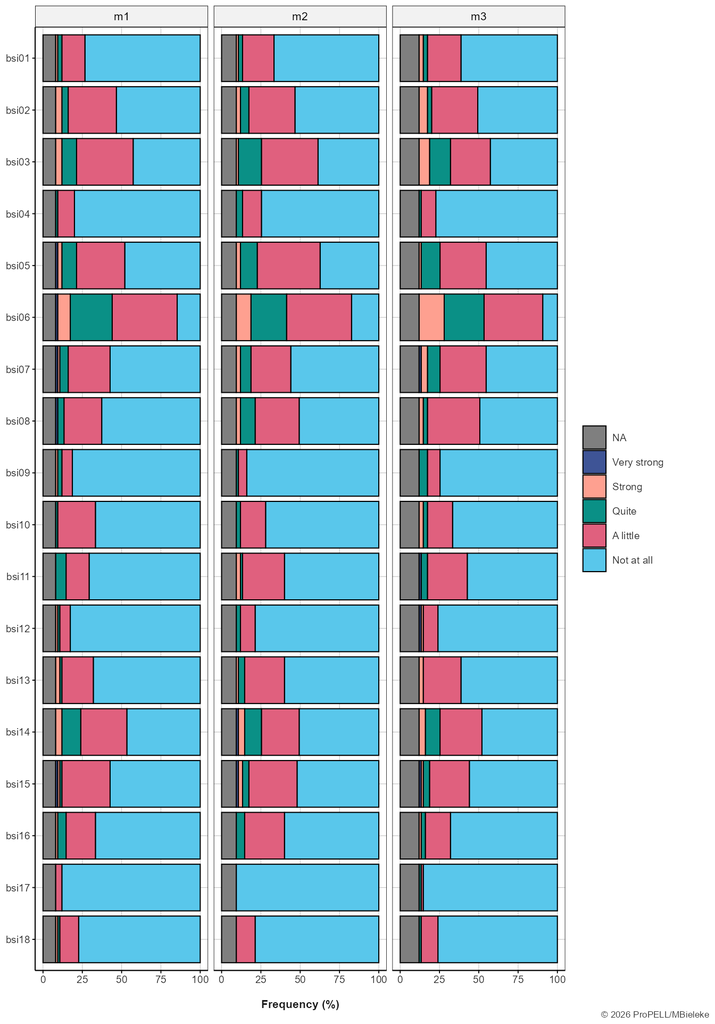

**Scale**

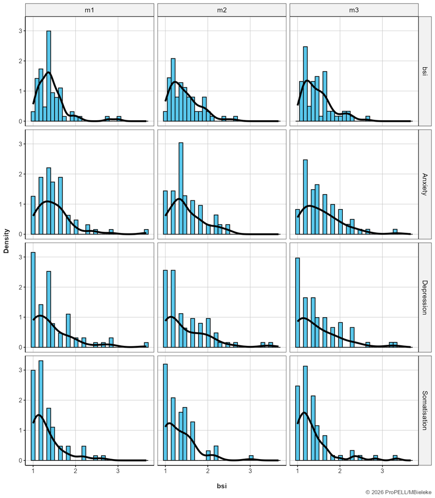

**Statistics**

**Items**

| Variable | N | #Valid | %Valid | Mean | SD | Min | Median | Max |
| --- | --- | --- | --- | --- | --- | --- | --- | --- |
| **bsi01** |  |  |  |  |  |  |  |  |
| m1 | 75 | 69 | 92.00 | 1.26 | 0.59 | 1 | 1 | 4 |
| m2 | 75 | 68 | 90.67 | 1.32 | 0.61 | 1 | 1 | 4 |
| m3 | 75 | 66 | 88.00 | 1.39 | 0.70 | 1 | 1 | 4 |
| **bsi02** |  |  |  |  |  |  |  |  |
| m1 | 75 | 69 | 92.00 | 1.55 | 0.78 | 1 | 1 | 4 |
| m2 | 75 | 68 | 90.67 | 1.53 | 0.74 | 1 | 1 | 4 |
| m3 | 75 | 66 | 88.00 | 1.58 | 0.82 | 1 | 1 | 4 |
| **bsi03** |  |  |  |  |  |  |  |  |
| m1 | 75 | 69 | 92.00 | 1.72 | 0.82 | 1 | 2 | 4 |
| m2 | 75 | 68 | 90.67 | 1.76 | 0.77 | 1 | 2 | 4 |
| m3 | 75 | 66 | 88.00 | 1.82 | 0.96 | 1 | 2 | 4 |
| **bsi04** |  |  |  |  |  |  |  |  |
| m1 | 75 | 69 | 92.00 | 1.14 | 0.39 | 1 | 1 | 3 |
| m2 | 75 | 68 | 90.67 | 1.22 | 0.51 | 1 | 1 | 3 |
| m3 | 75 | 66 | 88.00 | 1.14 | 0.39 | 1 | 1 | 3 |
| **bsi05** |  |  |  |  |  |  |  |  |
| m1 | 75 | 69 | 92.00 | 1.68 | 0.88 | 1 | 1 | 5 |
| m2 | 75 | 68 | 90.67 | 1.76 | 0.77 | 1 | 2 | 4 |
| m3 | 75 | 66 | 88.00 | 1.65 | 0.77 | 1 | 1 | 4 |
| **bsi06** |  |  |  |  |  |  |  |  |
| m1 | 75 | 69 | 92.00 | 2.35 | 0.90 | 1 | 2 | 5 |
| m2 | 75 | 68 | 90.67 | 2.26 | 0.89 | 1 | 2 | 4 |
| m3 | 75 | 66 | 88.00 | 2.55 | 0.91 | 1 | 2 | 4 |
| **bsi07** |  |  |  |  |  |  |  |  |
| m1 | 75 | 69 | 92.00 | 1.51 | 0.80 | 1 | 1 | 5 |
| m2 | 75 | 68 | 90.67 | 1.51 | 0.76 | 1 | 1 | 4 |
| m3 | 75 | 66 | 88.00 | 1.71 | 0.92 | 1 | 1 | 5 |
| **bsi08** |  |  |  |  |  |  |  |  |
| m1 | 75 | 69 | 92.00 | 1.41 | 0.71 | 1 | 1 | 5 |
| m2 | 75 | 68 | 90.67 | 1.60 | 0.79 | 1 | 1 | 4 |
| m3 | 75 | 66 | 88.00 | 1.53 | 0.71 | 1 | 1 | 4 |
| **bsi09** |  |  |  |  |  |  |  |  |
| m1 | 75 | 69 | 92.00 | 1.17 | 0.54 | 1 | 1 | 4 |
| m2 | 75 | 68 | 90.67 | 1.09 | 0.33 | 1 | 1 | 3 |
| m3 | 75 | 66 | 88.00 | 1.21 | 0.54 | 1 | 1 | 3 |
| **bsi10** |  |  |  |  |  |  |  |  |
| m1 | 75 | 69 | 92.00 | 1.29 | 0.49 | 1 | 1 | 3 |
| m2 | 75 | 68 | 90.67 | 1.24 | 0.49 | 1 | 1 | 3 |
| m3 | 75 | 66 | 88.00 | 1.33 | 0.69 | 1 | 1 | 4 |
| **bsi11** |  |  |  |  |  |  |  |  |
| m1 | 75 | 69 | 92.00 | 1.30 | 0.60 | 1 | 1 | 3 |
| m2 | 75 | 68 | 90.67 | 1.41 | 0.67 | 1 | 1 | 4 |
| m3 | 75 | 66 | 88.00 | 1.44 | 0.73 | 1 | 1 | 5 |
| **bsi12** |  |  |  |  |  |  |  |  |
| m1 | 75 | 69 | 92.00 | 1.14 | 0.49 | 1 | 1 | 4 |
| m2 | 75 | 68 | 90.67 | 1.16 | 0.44 | 1 | 1 | 3 |
| m3 | 75 | 66 | 88.00 | 1.21 | 0.67 | 1 | 1 | 5 |
| **bsi13** |  |  |  |  |  |  |  |  |
| m1 | 75 | 69 | 92.00 | 1.33 | 0.66 | 1 | 1 | 4 |
| m2 | 75 | 68 | 90.67 | 1.41 | 0.65 | 1 | 1 | 4 |
| m3 | 75 | 66 | 88.00 | 1.36 | 0.65 | 1 | 1 | 4 |
| **bsi14** |  |  |  |  |  |  |  |  |
| m1 | 75 | 69 | 92.00 | 1.71 | 0.86 | 1 | 1 | 4 |
| m2 | 75 | 68 | 90.67 | 1.69 | 0.95 | 1 | 1 | 5 |
| m3 | 75 | 66 | 88.00 | 1.65 | 0.85 | 1 | 1 | 4 |
| **bsi15** |  |  |  |  |  |  |  |  |
| m1 | 75 | 69 | 92.00 | 1.46 | 0.74 | 1 | 1 | 5 |
| m2 | 75 | 68 | 90.67 | 1.57 | 0.83 | 1 | 1 | 5 |
| m3 | 75 | 66 | 88.00 | 1.48 | 0.79 | 1 | 1 | 5 |
| **bsi16** |  |  |  |  |  |  |  |  |
| m1 | 75 | 69 | 92.00 | 1.36 | 0.66 | 1 | 1 | 4 |
| m2 | 75 | 68 | 90.67 | 1.40 | 0.60 | 1 | 1 | 3 |
| m3 | 75 | 66 | 88.00 | 1.29 | 0.60 | 1 | 1 | 4 |
| **bsi17** |  |  |  |  |  |  |  |  |
| m1 | 75 | 69 | 92.00 | 1.04 | 0.21 | 1 | 1 | 2 |
| m2 | 75 | 68 | 90.67 | 1.00 | 0.00 | 1 | 1 | 1 |
| m3 | 75 | 66 | 88.00 | 1.05 | 0.27 | 1 | 1 | 3 |
| **bsi18** |  |  |  |  |  |  |  |  |
| m1 | 75 | 69 | 92.00 | 1.20 | 0.53 | 1 | 1 | 4 |
| m2 | 75 | 68 | 90.67 | 1.13 | 0.34 | 1 | 1 | 2 |
| m3 | 75 | 66 | 88.00 | 1.15 | 0.40 | 1 | 1 | 3 |

**Scale**

| Variable | N | #Valid | %Valid | SD | Mean | Min | Median | Max | #Items | Alpha |
| --- | --- | --- | --- | --- | --- | --- | --- | --- | --- | --- |
| **bsi** |  |  |  |  |  |  |  |  |  |  |
| m1 | 75 | 69 | 92.00 | 0.35 | 1.43 | 1.00 | 1.39 | 3.00 | 18 | 0.84 |
| m2 | 75 | 68 | 90.67 | 0.34 | 1.45 | 1.00 | 1.33 | 2.61 | 18 | 0.84 |
| m3 | 75 | 66 | 88.00 | 0.34 | 1.47 | 1.06 | 1.39 | 2.61 | 18 | 0.80 |
| **bsianx** |  |  |  |  |  |  |  |  |  |  |
| m1 | 75 | 69 | 92.00 | 0.46 | 1.51 | 1.00 | 1.50 | 3.67 | 6 | 0.74 |
| m2 | 75 | 68 | 90.67 | 0.39 | 1.50 | 1.00 | 1.33 | 2.50 | 6 | 0.65 |
| m3 | 75 | 66 | 88.00 | 0.46 | 1.57 | 1.00 | 1.50 | 3.33 | 6 | 0.68 |
| **bsidep** |  |  |  |  |  |  |  |  |  |  |
| m1 | 75 | 69 | 92.00 | 0.53 | 1.45 | 1.00 | 1.33 | 3.67 | 6 | 0.84 |
| m2 | 75 | 68 | 90.67 | 0.55 | 1.50 | 1.00 | 1.33 | 3.50 | 6 | 0.88 |
| m3 | 75 | 66 | 88.00 | 0.53 | 1.48 | 1.00 | 1.33 | 3.33 | 6 | 0.83 |
| **bsisom** |  |  |  |  |  |  |  |  |  |  |
| m1 | 75 | 69 | 92.00 | 0.37 | 1.32 | 1.00 | 1.17 | 2.67 | 6 | 0.65 |
| m2 | 75 | 68 | 90.67 | 0.38 | 1.35 | 1.00 | 1.33 | 3.00 | 6 | 0.67 |
| m3 | 75 | 66 | 88.00 | 0.45 | 1.37 | 1.00 | 1.17 | 3.33 | 6 | 0.75 |